# Mert Erdinc BADS Final Assignment

#### Brand ID

```python
woe_x = IV_Calc_all(dfk_all_copy, feature="brand_id", target="return")
iv= woe_x.final_assessment()
```

```
The variable brand_id is highly predictive with an IV of: inf
```

```python
brand_id_table_all=woe_x.full_summary()  #we observe which brands have IV values
brand_id_table_all.tail(40)              #we will also use this table in the WoE encoding of the unknown data
#Interesting is that, for example, brand 86 has been kept in all of the purchases unlike most of the other brands
```

|  | Count | Bad | Good | Ratio Bad | Ratio Good | Distribution Bad | Distribution Good | WOE | WOE_adj | IV |
| --- | --- | --- | --- | --- | --- | --- | --- | --- | --- | --- |
| 59 | 45 | 14 | 31 | 0.311111 | 0.688889 | 0.000308 | 0.000702 | 0.823340 | 0.804249 | 3.244142e-04 |
| 128 | 42 | 20 | 22 | 0.476190 | 0.523810 | 0.000440 | 0.000498 | 0.123720 | 0.121500 | 7.176006e-06 |
| 86 | 34 | 0 | 34 | 0.000000 | 1.000000 | 0.000000 | 0.000770 | inf | 4.262516 | inf |
| 76 | 32 | 19 | 13 | 0.593750 | 0.406250 | 0.000418 | 0.000295 | -0.351080 | -0.339315 | 4.348970e-05 |
| 126 | 31 | 0 | 31 | 0.000000 | 1.000000 | 0.000000 | 0.000702 | inf | 4.171545 | inf |
| 71 | 29 | 5 | 24 | 0.172414 | 0.827586 | 0.000110 | 0.000544 | 1.597026 | 1.522335 | 6.925047e-04 |
| 81 | 26 | 20 | 6 | 0.769231 | 0.230769 | 0.000440 | 0.000136 | -1.175563 | -1.120213 | 3.579367e-04 |
| 52 | 22 | 12 | 10 | 0.545455 | 0.454545 | 0.000264 | 0.000227 | -0.153912 | -0.145943 | 5.801767e-06 |
| 127 | 22 | 9 | 13 | 0.409091 | 0.590909 | 0.000198 | 0.000295 | 0.396135 | 0.379808 | 3.816043e-05 |
| 65 | 21 | 4 | 17 | 0.190476 | 0.809524 | 0.000088 | 0.000385 | 1.475329 | 1.386533 | 4.382550e-04 |
| 91 | 20 | 11 | 9 | 0.550000 | 0.450000 | 0.000242 | 0.000204 | -0.172261 | -0.162645 | 6.602758e-06 |
| 92 | 19 | 13 | 6 | 0.684211 | 0.315789 | 0.000286 | 0.000136 | -0.744780 | -0.702478 | 1.119678e-04 |
| 132 | 12 | 0 | 12 | 0.000000 | 1.000000 | 0.000000 | 0.000272 | inf | 3.247286 | inf |
| 112 | 12 | 0 | 12 | 0.000000 | 1.000000 | 0.000000 | 0.000272 | inf | 3.247286 | inf |
| 99 | 12 | 5 | 7 | 0.416667 | 0.583333 | 0.000110 | 0.000159 | 0.364882 | 0.338565 | 1.769068e-05 |
| 83 | 11 | 3 | 8 | 0.272727 | 0.727273 | 0.000066 | 0.000181 | 1.009239 | 0.915713 | 1.162438e-04 |
| 108 | 8 | 5 | 3 | 0.625000 | 0.375000 | 0.000110 | 0.000068 | -0.482416 | -0.423575 | 2.032779e-05 |
| 131 | 6 | 2 | 4 | 0.333333 | 0.666667 | 0.000044 | 0.000091 | 0.721557 | 0.616197 | 3.360979e-05 |
| 88 | 6 | 5 | 1 | 0.833333 | 0.166667 | 0.000110 | 0.000023 | -1.581028 | -1.270873 | 1.382575e-04 |
| 67 | 5 | 0 | 5 | 0.000000 | 1.000000 | 0.000000 | 0.000113 | inf | 2.426305 | inf |
| 98 | 5 | 2 | 3 | 0.400000 | 0.600000 | 0.000044 | 0.000068 | 0.433875 | 0.364882 | 1.038018e-05 |
| 134 | 5 | 0 | 5 | 0.000000 | 1.000000 | 0.000000 | 0.000113 | inf | 2.426305 | inf |
| 107 | 5 | 3 | 2 | 0.600000 | 0.400000 | 0.000066 | 0.000045 | -0.377055 | -0.308062 | 7.824443e-06 |
| 130 | 5 | 0 | 5 | 0.000000 | 1.000000 | 0.000000 | 0.000113 | inf | 2.426305 | inf |
| 85 | 4 | 1 | 3 | 0.250000 | 0.750000 | 0.000022 | 0.000068 | 1.127022 | 0.875708 | 5.178099e-05 |
| 103 | 4 | 2 | 2 | 0.500000 | 0.500000 | 0.000044 | 0.000045 | 0.028410 | 0.028410 | 3.605663e-08 |
| 82 | 4 | 2 | 2 | 0.500000 | 0.500000 | 0.000044 | 0.000045 | 0.028410 | 0.028410 | 3.605663e-08 |
| 138 | 3 | 1 | 2 | 0.333333 | 0.666667 | 0.000022 | 0.000045 | 0.721557 | 0.539236 | 1.680490e-05 |
| 79 | 3 | 1 | 2 | 0.333333 | 0.666667 | 0.000022 | 0.000045 | 0.721557 | 0.539236 | 1.680490e-05 |
| 129 | 1 | 0 | 1 | 0.000000 | 1.000000 | 0.000000 | 0.000023 | inf | 1.127022 | inf |
| 135 | 1 | 0 | 1 | 0.000000 | 1.000000 | 0.000000 | 0.000023 | inf | 1.127022 | inf |
| 133 | 1 | 0 | 1 | 0.000000 | 1.000000 | 0.000000 | 0.000023 | inf | 1.127022 | inf |
| 115 | 1 | 0 | 1 | 0.000000 | 1.000000 | 0.000000 | 0.000023 | inf | 1.127022 | inf |
| 121 | 1 | 0 | 1 | 0.000000 | 1.000000 | 0.000000 | 0.000023 | inf | 1.127022 | inf |
| 106 | 1 | 0 | 1 | 0.000000 | 1.000000 | 0.000000 | 0.000023 | inf | 1.127022 | inf |
| 105 | 1 | 1 | 0 | 1.000000 | 0.000000 | 0.000022 | 0.000000 | -inf | -1.070202 | inf |
| 100 | 1 | 1 | 0 | 1.000000 | 0.000000 | 0.000022 | 0.000000 | -inf | -1.070202 | inf |
| 125 | 0 | 0 | 0 | NaN | NaN | 0.000000 | 0.000000 | NaN | 0.028410 | NaN |
| 136 | 0 | 0 | 0 | NaN | NaN | 0.000000 | 0.000000 | NaN | 0.028410 | NaN |
| 137 | 0 | 0 | 0 | NaN | NaN | 0.000000 | 0.000000 | NaN | 0.028410 | NaN |

If we knew which brands were these, we could likely derive some insights such as low-segment products are returned more or the like.

```python
woe_x = IV_Calc_all(dfk_all_copy, feature="brand_id", target="return")  #to WoE encode the unknown data later
iv= woe_x.final_assessment()
brand_id_table_all=woe_x.full_summary()
brand_id_table_all.tail(40)
```

```
The variable brand_id is highly predictive with an IV of: inf
```

|  | Count | Bad | Good | Ratio Bad | Ratio Good | Distribution Bad | Distribution Good | WOE | WOE_adj | IV |
| --- | --- | --- | --- | --- | --- | --- | --- | --- | --- | --- |
| 59 | 45 | 14 | 31 | 0.311111 | 0.688889 | 0.000308 | 0.000702 | 0.823340 | 0.804249 | 3.244142e-04 |
| 128 | 42 | 20 | 22 | 0.476190 | 0.523810 | 0.000440 | 0.000498 | 0.123720 | 0.121500 | 7.176006e-06 |
| 86 | 34 | 0 | 34 | 0.000000 | 1.000000 | 0.000000 | 0.000770 | inf | 4.262516 | inf |
| 76 | 32 | 19 | 13 | 0.593750 | 0.406250 | 0.000418 | 0.000295 | -0.351080 | -0.339315 | 4.348970e-05 |
| 126 | 31 | 0 | 31 | 0.000000 | 1.000000 | 0.000000 | 0.000702 | inf | 4.171545 | inf |
| 71 | 29 | 5 | 24 | 0.172414 | 0.827586 | 0.000110 | 0.000544 | 1.597026 | 1.522335 | 6.925047e-04 |
| 81 | 26 | 20 | 6 | 0.769231 | 0.230769 | 0.000440 | 0.000136 | -1.175563 | -1.120213 | 3.579367e-04 |
| 52 | 22 | 12 | 10 | 0.545455 | 0.454545 | 0.000264 | 0.000227 | -0.153912 | -0.145943 | 5.801767e-06 |
| 127 | 22 | 9 | 13 | 0.409091 | 0.590909 | 0.000198 | 0.000295 | 0.396135 | 0.379808 | 3.816043e-05 |
| 65 | 21 | 4 | 17 | 0.190476 | 0.809524 | 0.000088 | 0.000385 | 1.475329 | 1.386533 | 4.382550e-04 |
| 91 | 20 | 11 | 9 | 0.550000 | 0.450000 | 0.000242 | 0.000204 | -0.172261 | -0.162645 | 6.602758e-06 |
| 92 | 19 | 13 | 6 | 0.684211 | 0.315789 | 0.000286 | 0.000136 | -0.744780 | -0.702478 | 1.119678e-04 |
| 132 | 12 | 0 | 12 | 0.000000 | 1.000000 | 0.000000 | 0.000272 | inf | 3.247286 | inf |
| 112 | 12 | 0 | 12 | 0.000000 | 1.000000 | 0.000000 | 0.000272 | inf | 3.247286 | inf |
| 99 | 12 | 5 | 7 | 0.416667 | 0.583333 | 0.000110 | 0.000159 | 0.364882 | 0.338565 | 1.769068e-05 |
| 83 | 11 | 3 | 8 | 0.272727 | 0.727273 | 0.000066 | 0.000181 | 1.009239 | 0.915713 | 1.162438e-04 |
| 108 | 8 | 5 | 3 | 0.625000 | 0.375000 | 0.000110 | 0.000068 | -0.482416 | -0.423575 | 2.032779e-05 |
| 131 | 6 | 2 | 4 | 0.333333 | 0.666667 | 0.000044 | 0.000091 | 0.721557 | 0.616197 | 3.360979e-05 |
| 88 | 6 | 5 | 1 | 0.833333 | 0.166667 | 0.000110 | 0.000023 | -1.581028 | -1.270873 | 1.382575e-04 |
| 67 | 5 | 0 | 5 | 0.000000 | 1.000000 | 0.000000 | 0.000113 | inf | 2.426305 | inf |
| 98 | 5 | 2 | 3 | 0.400000 | 0.600000 | 0.000044 | 0.000068 | 0.433875 | 0.364882 | 1.038018e-05 |
| 134 | 5 | 0 | 5 | 0.000000 | 1.000000 | 0.000000 | 0.000113 | inf | 2.426305 | inf |
| 107 | 5 | 3 | 2 | 0.600000 | 0.400000 | 0.000066 | 0.000045 | -0.377055 | -0.308062 | 7.824443e-06 |
| 130 | 5 | 0 | 5 | 0.000000 | 1.000000 | 0.000000 | 0.000113 | inf | 2.426305 | inf |
| 85 | 4 | 1 | 3 | 0.250000 | 0.750000 | 0.000022 | 0.000068 | 1.127022 | 0.875708 | 5.178099e-05 |
| 103 | 4 | 2 | 2 | 0.500000 | 0.500000 | 0.000044 | 0.000045 | 0.028410 | 0.028410 | 3.605663e-08 |
| 82 | 4 | 2 | 2 | 0.500000 | 0.500000 | 0.000044 | 0.000045 | 0.028410 | 0.028410 | 3.605663e-08 |
| 138 | 3 | 1 | 2 | 0.333333 | 0.666667 | 0.000022 | 0.000045 | 0.721557 | 0.539236 | 1.680490e-05 |
| 79 | 3 | 1 | 2 | 0.333333 | 0.666667 | 0.000022 | 0.000045 | 0.721557 | 0.539236 | 1.680490e-05 |
| 129 | 1 | 0 | 1 | 0.000000 | 1.000000 | 0.000000 | 0.000023 | inf | 1.127022 | inf |
| 135 | 1 | 0 | 1 | 0.000000 | 1.000000 | 0.000000 | 0.000023 | inf | 1.127022 | inf |
| 133 | 1 | 0 | 1 | 0.000000 | 1.000000 | 0.000000 | 0.000023 | inf | 1.127022 | inf |
| 115 | 1 | 0 | 1 | 0.000000 | 1.000000 | 0.000000 | 0.000023 | inf | 1.127022 | inf |
| 121 | 1 | 0 | 1 | 0.000000 | 1.000000 | 0.000000 | 0.000023 | inf | 1.127022 | inf |
| 106 | 1 | 0 | 1 | 0.000000 | 1.000000 | 0.000000 | 0.000023 | inf | 1.127022 | inf |
| 105 | 1 | 1 | 0 | 1.000000 | 0.000000 | 0.000022 | 0.000000 | -inf | -1.070202 | inf |
| 100 | 1 | 1 | 0 | 1.000000 | 0.000000 | 0.000022 | 0.000000 | -inf | -1.070202 | inf |
| 125 | 0 | 0 | 0 | NaN | NaN | 0.000000 | 0.000000 | NaN | 0.028410 | NaN |
| 136 | 0 | 0 | 0 | NaN | NaN | 0.000000 | 0.000000 | NaN | 0.028410 | NaN |
| 137 | 0 | 0 | 0 | NaN | NaN | 0.000000 | 0.000000 | NaN | 0.028410 | NaN |

```python
brand_id_table_all.nlargest(16, ['IV']).IV   #15 inf values #we find out which brands have inf value as IV for sure
```

```
86          inf
126         inf
132         inf
112         inf
67          inf
134         inf
130         inf
129         inf
135         inf
133         inf
115         inf
121         inf
106         inf
105         inf
100         inf
3      0.022427
Name: IV, dtype: float64
```

```python
dfk_all_copy = dfk_all_copy[dfk_all_copy["brand_id"] != (86)]
dfk_all_copy = dfk_all_copy[dfk_all_copy["brand_id"] != (126)]
dfk_all_copy = dfk_all_copy[dfk_all_copy["brand_id"] != (112)]
dfk_all_copy = dfk_all_copy[dfk_all_copy["brand_id"] != (132)]
dfk_all_copy = dfk_all_copy[dfk_all_copy["brand_id"] != (67)]
dfk_all_copy = dfk_all_copy[dfk_all_copy["brand_id"] != (130)]
dfk_all_copy = dfk_all_copy[dfk_all_copy["brand_id"] != (134)]
dfk_all_copy = dfk_all_copy[dfk_all_copy["brand_id"] != (79)]
dfk_all_copy = dfk_all_copy[dfk_all_copy["brand_id"] != (129)]
dfk_all_copy = dfk_all_copy[dfk_all_copy["brand_id"] != (133)]
dfk_all_copy = dfk_all_copy[dfk_all_copy["brand_id"] != (115)]
dfk_all_copy = dfk_all_copy[dfk_all_copy["brand_id"] != (106)]
dfk_all_copy = dfk_all_copy[dfk_all_copy["brand_id"] != (105)]
dfk_all_copy = dfk_all_copy[dfk_all_copy["brand_id"] != (100)]
dfk_all_copy = dfk_all_copy[dfk_all_copy["brand_id"] != (85)]
dfk_all_copy = dfk_all_copy[dfk_all_copy["brand_id"] != (135)]
dfk_all_copy = dfk_all_copy[dfk_all_copy["brand_id"] != (121)]
dfk_all_copy.brand_id.value_counts()
```

```
3      10378
1       7369
37      4493
5       4097
11      4023
       ...
105        0
100        0
86         0
85         0
67         0
Name: brand_id, Length: 133, dtype: int64
```

```python
woe_x = IV_Calc_all(dfk_all_copy, feature="brand_id", target="return")
woe_x.final_assessment()
```

```
The variable brand_id is moderately predictive with an IV of:0.1570601881028612
```

```
0.1570601881028612
```

We learn that brand id is one of the variables that are among the most important ones to use it during building the prediction model.

```python
class IV_Calc_train:   #the same code but only to get WoE values for the training set
    def __init__(self, dfk_train_copy, feature, target):
        self.feature = feature
        self.target = target
        self.data_head = dfk_train_copy.head()

    def count_values(self):
        data = pd.DataFrame()
        data['Count'] = dfk_train_copy[self.feature].value_counts()               # Count instances of each category, create row for each
        data['Bad'] = dfk_train_copy.groupby([self.feature])[self.target].sum()   # Count y=1 instances of that category
        data['Good'] = data['Count'] - data['Bad']                    # Count y=0 instances of that category
        data = data.sort_values(by=["Count"], ascending=False)

        try:
            assert data["Bad"].sum() != 0                               # Check that there are y=1 instances in sample
            assert data["Good"].sum() != 0                              # Check that there are y=0 instances in sample
            assert np.isin(dfk_train_copy[self.target].unique(), [0, 1]).all()      # Check that target includes only 0,1 or True,False
        except:
          print("Error: Target must include 2 binary classes.")
          raise                                                       # Stop running if one of the above conditions is not satisfied

        return data

    def distribution(self):
        data = self.count_values()
        data['Ratio Bad'] = data['Bad'] / data['Count']
        data['Ratio Good'] = data['Good'] / data['Count']
        data["Distribution Bad"] = data["Bad"] / data["Bad"].sum()    # Of all y=0 instances, what percentage are from each category?
        data["Distribution Good"] = data["Good"] / data["Good"].sum() # Of all y=1 instances, what percentage are from each category?
        data = data.sort_values(by=["Count"], ascending=False)
        return data.iloc[:,-2:]

    def woe(self):
        data = self.distribution()
        data['WOE'] = np.log(data["Distribution Good"] / data["Distribution Bad"])
        data.replace({"WOE": {np.inf: 0, -np.inf: 0}})  # If no instances are bad, this will replace values of infinity with 0
        data = data.sort_values(by=["WOE"], ascending=False)
        return data.iloc[:,-1]

    def woe_adj(self):
        data = self.count_values()
        data["WOE_adj"] = np.log(
            ((data["Count"] - data["Bad"] + 0.5) / (data["Count"].sum() - data["Bad"].sum())) /
            ((data["Bad"] + 0.5) / data["Bad"].sum())
            )
        data.replace({"WOE_adj": {np.inf: 0, -np.inf: 0}})
        data = data.sort_values(by=["Count"], ascending=False)
        return data.iloc[:,-1]

    def IV_per_cat(self):
        data = self.distribution()
        data['WOE'] = self.woe()
        data["IV"] = data["WOE"]*(data["Distribution Good"] - data["Distribution Bad"])
        data = data.sort_values(by=["IV"], ascending=False)
        return data.iloc[:,-1]

    def full_summary(self):
        data = self.count_values()
        data['Ratio Bad'] = data['Bad'] / data['Count']
        data['Ratio Good'] = data['Good'] / data['Count']
        data["Distribution Bad"] = data["Bad"] / data["Bad"].sum()
        data["Distribution Good"] = data["Good"] / data["Good"].sum()
        data['WOE'] = self.woe()
        data["WOE_adj"] = self.woe_adj()
        data["IV"] = self.IV_per_cat()
        data = data.sort_values(by=["Count"], ascending=False)
        return data

    def final_assessment(self):
        data = self.full_summary()
        iv = data["IV"].sum() # final IV value
        if iv < .02:
            print("The variable " + self.feature + " is not predictive with an IV of: {}".format(iv))
        elif iv < .1:
            print("The variable " + self.feature + " is weakly predictive with an IV of:{}".format(iv))
        elif iv < .3:
            print("The variable " + self.feature + " is moderately predictive with an IV of:{}".format(iv))
        else :
            print("The variable " + self.feature + " is highly predictive with an IV of: {}".format(iv))
        return iv
```

```python
woe_x_test = IV_Calc_train(dfk_train, feature="brand_id", target="return")
iv_test= woe_x_test.final_assessment()
brand_id_table_train=woe_x_test.full_summary() #To be used in WoE encoding of the training set
brand_id_table_train
```

```
The variable brand_id is highly predictive with an IV of: inf
```

|  | Count | Bad | Good | Ratio Bad | Ratio Good | Distribution Bad | Distribution Good | WOE | WOE_adj | IV |
| --- | --- | --- | --- | --- | --- | --- | --- | --- | --- | --- |
| 3 | 7276 | 2903 | 4373 | 0.398983 | 0.601017 | 0.091572 | 0.141691 | 0.436526 | 0.436468 | 0.021878 |
| 1 | 5245 | 2885 | 2360 | 0.550048 | 0.449952 | 0.091004 | 0.076467 | -0.174042 | -0.174003 | 0.002530 |
| 37 | 3168 | 1412 | 1756 | 0.445707 | 0.554293 | 0.044540 | 0.056897 | 0.244853 | 0.244784 | 0.003026 |
| 5 | 2871 | 1324 | 1547 | 0.461163 | 0.538837 | 0.041764 | 0.050125 | 0.182482 | 0.182427 | 0.001526 |
| 11 | 2800 | 1692 | 1108 | 0.604286 | 0.395714 | 0.053372 | 0.035901 | -0.396533 | -0.396377 | 0.006928 |
| ... | ... | ... | ... | ... | ... | ... | ... | ... | ... | ... |
| 125 | 0 | 0 | 0 | NaN | NaN | 0.000000 | 0.000000 | NaN | 0.026822 | NaN |
| 121 | 0 | 0 | 0 | NaN | NaN | 0.000000 | 0.000000 | NaN | 0.026822 | NaN |
| 135 | 0 | 0 | 0 | NaN | NaN | 0.000000 | 0.000000 | NaN | 0.026822 | NaN |
| 136 | 0 | 0 | 0 | NaN | NaN | 0.000000 | 0.000000 | NaN | 0.026822 | NaN |
| 137 | 0 | 0 | 0 | NaN | NaN | 0.000000 | 0.000000 | NaN | 0.026822 | NaN |

133 rows × 10 columns

```python
class IV_Calc_test:    #the same code but only to get WoE values for the test set
    def __init__(self, dfk_test_copy, feature, target):
        self.feature = feature
        self.target = target
        self.data_head = dfk_test_copy.head()

    def count_values(self):
        data = pd.DataFrame()
        data['Count'] = dfk_test_copy[self.feature].value_counts()               # Count instances of each category, create row for each
        data['Bad'] = dfk_test_copy.groupby([self.feature])[self.target].sum()   # Count y=1 instances of that category
        data['Good'] = data['Count'] - data['Bad']                    # Count y=0 instances of that category
        data = data.sort_values(by=["Count"], ascending=False)

        try:
            assert data["Bad"].sum() != 0                               # Check that there are y=1 instances in sample
            assert data["Good"].sum() != 0                              # Check that there are y=0 instances in sample
            assert np.isin(dfk_test_copy[self.target].unique(), [0, 1]).all()      # Check that target includes only 0,1 or True,False
        except:
          print("Error: Target must include 2 binary classes.")
          raise                                                       # Stop running if one of the above conditions is not satisfied

        return data

    def distribution(self):
        data = self.count_values()
        data['Ratio Bad'] = data['Bad'] / data['Count']
        data['Ratio Good'] = data['Good'] / data['Count']
        data["Distribution Bad"] = data["Bad"] / data["Bad"].sum()    # Of all y=0 instances, what percentage are from each category?
        data["Distribution Good"] = data["Good"] / data["Good"].sum() # Of all y=1 instances, what percentage are from each category?
        data = data.sort_values(by=["Count"], ascending=False)
        return data.iloc[:,-2:]

    def woe(self):
        data = self.distribution()
        data['WOE'] = np.log(data["Distribution Good"] / data["Distribution Bad"])
        data.replace({"WOE": {np.inf: 0, -np.inf: 0}})  # If no instances are bad, this will replace values of infinity with 0
        data = data.sort_values(by=["WOE"], ascending=False)
        return data.iloc[:,-1]

    def woe_adj(self):
        data = self.count_values()
        data["WOE_adj"] = np.log(
            ((data["Count"] - data["Bad"] + 0.5) / (data["Count"].sum() - data["Bad"].sum())) /
            ((data["Bad"] + 0.5) / data["Bad"].sum())
            )
        data.replace({"WOE_adj": {np.inf: 0, -np.inf: 0}})
        data = data.sort_values(by=["Count"], ascending=False)
        return data.iloc[:,-1]

    def IV_per_cat(self):
        data = self.distribution()
        data['WOE'] = self.woe()
        data["IV"] = data["WOE"]*(data["Distribution Good"] - data["Distribution Bad"])
        data = data.sort_values(by=["IV"], ascending=False)
        return data.iloc[:,-1]

    def full_summary(self):
        data = self.count_values()
        data['Ratio Bad'] = data['Bad'] / data['Count']
        data['Ratio Good'] = data['Good'] / data['Count']
        data["Distribution Bad"] = data["Bad"] / data["Bad"].sum()
        data["Distribution Good"] = data["Good"] / data["Good"].sum()
        data['WOE'] = self.woe()
        data["WOE_adj"] = self.woe_adj()
        data["IV"] = self.IV_per_cat()
        data = data.sort_values(by=["Count"], ascending=False)
        return data

    def final_assessment(self):
        data = self.full_summary()
        iv = data["IV"].sum() # final IV value
        if iv < .02:
            print("The variable " + self.feature + " is not predictive with an IV of: {}".format(iv))
        elif iv < .1:
            print("The variable " + self.feature + " is weakly predictive with an IV of:{}".format(iv))
        elif iv < .3:
            print("The variable " + self.feature + " is moderately predictive with an IV of:{}".format(iv))
        else :
            print("The variable " + self.feature + " is highly predictive with an IV of: {}".format(iv))
        return iv
```

```python
woe_x_test = IV_Calc_test(dfk_test, feature="brand_id", target="return")
iv_test= woe_x_test.final_assessment()
brand_id_table_test=woe_x_test.full_summary() #To be used in WoE encoding of the test set
brand_id_table_test                           #One can also observe the difference between the WOE_adj values of the two tables
```

```
The variable brand_id is highly predictive with an IV of: inf
```

|  | Count | Bad | Good | Ratio Bad | Ratio Good | Distribution Bad | Distribution Good | WOE | WOE_adj | IV |
| --- | --- | --- | --- | --- | --- | --- | --- | --- | --- | --- |
| 3 | 3102 | 1226 | 1876 | 0.395229 | 0.604771 | 0.089424 | 0.141297 | 0.457477 | 0.457336 | 0.023731 |
| 1 | 2124 | 1163 | 961 | 0.547552 | 0.452448 | 0.084829 | 0.072381 | -0.158691 | -0.158601 | 0.001975 |
| 37 | 1325 | 612 | 713 | 0.461887 | 0.538113 | 0.044639 | 0.053702 | 0.184841 | 0.184726 | 0.001675 |
| 5 | 1226 | 606 | 620 | 0.494290 | 0.505710 | 0.044201 | 0.046697 | 0.054932 | 0.054913 | 0.000137 |
| 11 | 1223 | 735 | 488 | 0.600981 | 0.399019 | 0.053611 | 0.036755 | -0.377463 | -0.377119 | 0.006362 |
| ... | ... | ... | ... | ... | ... | ... | ... | ... | ... | ... |
| 106 | 0 | 0 | 0 | NaN | NaN | 0.000000 | 0.000000 | NaN | 0.032092 | NaN |
| 105 | 0 | 0 | 0 | NaN | NaN | 0.000000 | 0.000000 | NaN | 0.032092 | NaN |
| 103 | 0 | 0 | 0 | NaN | NaN | 0.000000 | 0.000000 | NaN | 0.032092 | NaN |
| 100 | 0 | 0 | 0 | NaN | NaN | 0.000000 | 0.000000 | NaN | 0.032092 | NaN |
| 67 | 0 | 0 | 0 | NaN | NaN | 0.000000 | 0.000000 | NaN | 0.032092 | NaN |

133 rows × 10 columns

We did this because WoE encoding numerical variables that represent categories using scorecardpy can be problematic as it automatically bins numeric values.

```python
dfk_train_copy = dfk_train_copy2  #converting the demo data to normal version to avoid omitting
dfk_test_copy = dfk_test_copy2  #some of the values that might matter for the next variables
dfk_all_copy =dfk_all2
```

#### Item ID

```python
woe_x = IV_Calc_all(dfk_all_copy, feature="item_id", target="return")
iv= woe_x.final_assessment()
```

```
The variable item_id is highly predictive with an IV of: inf
```

```python
item_id_table_all = woe_x.full_summary()  #to be used in the WoE encoding of the unknown data
item_id_table_all.head(20)
```

|  | Count | Bad | Good | Ratio Bad | Ratio Good | Distribution Bad | Distribution Good | WOE | WOE_adj | IV |
| --- | --- | --- | --- | --- | --- | --- | --- | --- | --- | --- |
| 1415 | 1015 | 333 | 682 | 0.328079 | 0.671921 | 0.007333 | 0.015451 | 0.745297 | 0.744530 | 0.006050 |
| 1532 | 964 | 363 | 601 | 0.376556 | 0.623444 | 0.007993 | 0.013616 | 0.532602 | 0.532057 | 0.002994 |
| 22 | 703 | 289 | 414 | 0.411095 | 0.588905 | 0.006364 | 0.009379 | 0.387849 | 0.387328 | 0.001169 |
| 1401 | 680 | 204 | 476 | 0.300000 | 0.700000 | 0.004492 | 0.010784 | 0.875708 | 0.874310 | 0.005510 |
| 100 | 659 | 409 | 250 | 0.620637 | 0.379363 | 0.009006 | 0.005664 | -0.463844 | -0.463068 | 0.001550 |
| 1470 | 604 | 276 | 328 | 0.456954 | 0.543046 | 0.006078 | 0.007431 | 0.201023 | 0.200736 | 0.000272 |
| 1546 | 593 | 322 | 271 | 0.543002 | 0.456998 | 0.007091 | 0.006140 | -0.144023 | -0.143731 | 0.000137 |
| 1607 | 574 | 330 | 244 | 0.574913 | 0.425087 | 0.007267 | 0.005528 | -0.273514 | -0.272981 | 0.000476 |
| 1445 | 519 | 302 | 217 | 0.581888 | 0.418112 | 0.006650 | 0.004916 | -0.302120 | -0.301472 | 0.000524 |
| 32 | 470 | 162 | 308 | 0.344681 | 0.655319 | 0.003567 | 0.006978 | 0.670913 | 0.669454 | 0.002288 |
| 1518 | 466 | 241 | 225 | 0.517167 | 0.482833 | 0.005307 | 0.005097 | -0.040287 | -0.040139 | 0.000008 |
| 1404 | 458 | 123 | 335 | 0.268559 | 0.731441 | 0.002709 | 0.007589 | 1.030356 | 1.027791 | 0.005029 |
| 242 | 438 | 282 | 156 | 0.643836 | 0.356164 | 0.006210 | 0.003534 | -0.563641 | -0.562213 | 0.001508 |
| 498 | 435 | 193 | 242 | 0.443678 | 0.556322 | 0.004250 | 0.005483 | 0.254658 | 0.254134 | 0.000314 |
| 255 | 409 | 176 | 233 | 0.430318 | 0.569682 | 0.003876 | 0.005279 | 0.308964 | 0.308271 | 0.000433 |
| 1630 | 408 | 253 | 155 | 0.620098 | 0.379902 | 0.005571 | 0.003512 | -0.461554 | -0.460308 | 0.000951 |
| 1628 | 390 | 145 | 245 | 0.371795 | 0.628205 | 0.003193 | 0.005551 | 0.552934 | 0.551531 | 0.001304 |
| 1505 | 375 | 144 | 231 | 0.384000 | 0.616000 | 0.003171 | 0.005233 | 0.501014 | 0.499710 | 0.001033 |
| 57 | 359 | 114 | 245 | 0.317549 | 0.682451 | 0.002510 | 0.005551 | 0.793470 | 0.791132 | 0.002412 |
| 1409 | 349 | 100 | 249 | 0.286533 | 0.713467 | 0.002202 | 0.005641 | 0.940693 | 0.937711 | 0.003235 |

```python
#woe_x.nlargest(10, woe_x['IV'])
item_id_table_all.nlargest(331, ['IV']).IV       #we have 330 out of 1915 inf values meaning that these specific items were
     #always returned or not returned. So, this variable will be decided based on other methods.
```

```
2085        inf
2148        inf
2021        inf
1951        inf
667         inf
         ...
1378        inf
1381        inf
1382        inf
1383        inf
1415    0.00605
Name: IV, Length: 331, dtype: float64
```

```python
df = pd.DataFrame(item_id_table_all.nlargest(330, ['IV']).IV)
df_indices=df.index
df_indices
indices=df_indices.tolist()
indices
```

[output not shown]

[output cut: 275 more lines]

```
 1342,
 954,
 952,
 1356,
 960,
 145,
 945,
 942,
 1371,
 1375,
 1376,
 1378,
 1381,
 1382,
 1383]
```

```python
dfk_all_copy=dfk_all_copy[~dfk_all_copy.item_id.isin(indices)]
dfk_all_copy
```

|  | item_id | item_color | brand_id | item_price | user_title | user_state | return | user_age | user_reg_time | order_day | delivery_day | delivery_dur | item_size_cat | item_size_num |
| --- | --- | --- | --- | --- | --- | --- | --- | --- | --- | --- | --- | --- | --- | --- |
| 2 | 270 | grey | 49 | 0.598029 | Mrs | Baden-Wuerttemberg | 1 | -0.728799 | 1.119513 | 1.588901 | 1.437021 | -0.175918 | xxl | -0.184952 |
| 3 | 142 | grey | 49 | 0.981662 | Mrs | Baden-Wuerttemberg | 0 | -0.728799 | 1.119513 | 1.588901 | 1.437021 | -0.175918 | xxl | -0.184952 |
| 5 | 579 | grey | 3 | -1.285924 | Mrs | Baden-Wuerttemberg | 1 | -0.728799 | 1.119513 | 1.588901 | 1.437021 | -0.175918 | xxl | -0.184952 |
| 6 | 72 | grey | 1 | 1.314432 | Mrs | Baden-Wuerttemberg | 0 | -0.728799 | 1.119513 | 1.588901 | 1.437021 | -0.175918 | numeric | 0.178792 |
| 8 | 195 | blue | 46 | -1.652637 | Mrs | Baden-Wuerttemberg | 1 | -0.728799 | 1.119513 | 1.588901 | 1.437021 | -0.175918 | xxl | -0.184952 |
| ... | ... | ... | ... | ... | ... | ... | ... | ... | ... | ... | ... | ... | ... | ... |
| 99989 | 1806 | berry | 110 | -1.416586 | Mrs | Lower Saxony | 1 | -0.004603 | -0.412536 | -1.714263 | -1.240336 | -0.506300 | unsized | -0.184952 |
| 99991 | 381 | pink | 1 | -0.034726 | Mrs | Baden-Wuerttemberg | 1 | 0.719593 | 1.119513 | -1.714263 | -1.275107 | -0.489433 | numeric | 0.143305 |
| 99994 | 1600 | green | 75 | 1.972933 | Mrs | Baden-Wuerttemberg | 0 | 0.719593 | 1.119513 | -1.714263 | -1.275107 | -0.489433 | xl | -0.184952 |
| 99995 | 156 | blue | 34 | -0.748864 | Mrs | Rhineland-Palatinate | 0 | 0.719593 | 1.119513 | -1.714263 | -1.240336 | -0.506300 | numeric | -0.007516 |
| 99996 | 156 | brown | 34 | -0.748864 | Mrs | Rhineland-Palatinate | 0 | 0.719593 | 1.119513 | -1.714263 | -1.240336 | -0.506300 | numeric | -0.007516 |

88752 rows × 14 columns

```python
woe_x = IV_Calc_all(dfk_all_copy, feature="item_id", target="return")
woe_x.final_assessment()
```

```
The variable item_id is highly predictive with an IV of: 0.4028463994744609
```

```
0.4028463994744609
```

The most predictive variable turns out to be the item id.

- Note: We omit the inf values but these can only be problematic if an IV value or Fisher score is just on the limit of being weakly predictive or not predictive because inf values will only increase to the filter method statistic.

```python
woe_x_train = IV_Calc_train(dfk_train_copy, feature="item_id", target="return") #This will be needed to WoE encode the training set
item_id_table_train=woe_x_train.full_summary()
item_id_table_train
```

|  | Count | Bad | Good | Ratio Bad | Ratio Good | Distribution Bad | Distribution Good | WOE | WOE_adj | IV |
| --- | --- | --- | --- | --- | --- | --- | --- | --- | --- | --- |
| 1415 | 715 | 225 | 490 | 0.314685 | 0.685315 | 0.007097 | 0.015877 | 0.805127 | 0.803927 | 0.007068 |
| 1532 | 661 | 243 | 418 | 0.367625 | 0.632375 | 0.007665 | 0.013544 | 0.569242 | 0.568382 | 0.003346 |
| 22 | 486 | 202 | 284 | 0.415638 | 0.584362 | 0.006372 | 0.009202 | 0.367528 | 0.366815 | 0.001040 |
| 1401 | 467 | 147 | 320 | 0.314775 | 0.685225 | 0.004637 | 0.010368 | 0.804710 | 0.802876 | 0.004612 |
| 100 | 464 | 278 | 186 | 0.599138 | 0.400862 | 0.008769 | 0.006027 | -0.375053 | -0.374165 | 0.001029 |
| ... | ... | ... | ... | ... | ... | ... | ... | ... | ... | ... |
| 387 | 0 | 0 | 0 | NaN | NaN | 0.000000 | 0.000000 | NaN | 0.026822 | NaN |
| 1725 | 0 | 0 | 0 | NaN | NaN | 0.000000 | 0.000000 | NaN | 0.026822 | NaN |
| 1819 | 0 | 0 | 0 | NaN | NaN | 0.000000 | 0.000000 | NaN | 0.026822 | NaN |
| 398 | 0 | 0 | 0 | NaN | NaN | 0.000000 | 0.000000 | NaN | 0.026822 | NaN |
| 559 | 0 | 0 | 0 | NaN | NaN | 0.000000 | 0.000000 | NaN | 0.026822 | NaN |

1915 rows × 10 columns

```python
woe_x_test = IV_Calc_test(dfk_test_copy, feature="item_id", target="return") #This will be needed to WoE encode the test set
item_id_table_test=woe_x_test.full_summary()
item_id_table_test                               #WoE_adj values that are different than the table above
```

|  | Count | Bad | Good | Ratio Bad | Ratio Good | Distribution Bad | Distribution Good | WOE | WOE_adj | IV |
| --- | --- | --- | --- | --- | --- | --- | --- | --- | --- | --- |
| 1532 | 303 | 120 | 183 | 0.396040 | 0.603960 | 0.008753 | 0.013783 | 0.454087 | 0.452657 | 0.002284 |
| 1415 | 300 | 108 | 192 | 0.360000 | 0.640000 | 0.007877 | 0.014461 | 0.607456 | 0.605438 | 0.003999 |
| 22 | 217 | 87 | 130 | 0.400922 | 0.599078 | 0.006346 | 0.009791 | 0.433719 | 0.431827 | 0.001494 |
| 1401 | 213 | 57 | 156 | 0.267606 | 0.732394 | 0.004158 | 0.011750 | 1.038897 | 1.033363 | 0.007887 |
| 100 | 195 | 131 | 64 | 0.671795 | 0.328205 | 0.009555 | 0.004820 | -0.684222 | -0.680249 | 0.003240 |
| ... | ... | ... | ... | ... | ... | ... | ... | ... | ... | ... |
| 1111 | 0 | 0 | 0 | NaN | NaN | 0.000000 | 0.000000 | NaN | 0.032092 | NaN |
| 1107 | 0 | 0 | 0 | NaN | NaN | 0.000000 | 0.000000 | NaN | 0.032092 | NaN |
| 274 | 0 | 0 | 0 | NaN | NaN | 0.000000 | 0.000000 | NaN | 0.032092 | NaN |
| 1102 | 0 | 0 | 0 | NaN | NaN | 0.000000 | 0.000000 | NaN | 0.032092 | NaN |
| 1145 | 0 | 0 | 0 | NaN | NaN | 0.000000 | 0.000000 | NaN | 0.032092 | NaN |

1915 rows × 10 columns

```python
dfk_train_copy = dfk_train_copy2  #converting the demo data to normal version to avoid omitting
dfk_test_copy = dfk_test_copy2  #some of the values that might matter for the next variables
dfk_all_copy =dfk_all2
```

#### User Title & User State

```python
woe_x = IV_Calc_all(dfk_all_copy, feature="user_state", target="return")  #to WoE encode the unknown data later
iv= woe_x.final_assessment()
user_state_table_all=woe_x.full_summary()
user_state_table_all.tail(10)
```

```
The variable user_state is not predictive with an IV of: 0.0023484508809664814
```

|  | Count | Bad | Good | Ratio Bad | Ratio Good | Distribution Bad | Distribution Good | WOE | WOE_adj | IV |
| --- | --- | --- | --- | --- | --- | --- | --- | --- | --- | --- |
| Rhineland-Palatinate | 4339 | 2157 | 2182 | 0.497119 | 0.502881 | 0.047498 | 0.049434 | 0.039934 | 0.039931 | 7.727779e-05 |
| Berlin | 3612 | 1847 | 1765 | 0.511351 | 0.488649 | 0.040672 | 0.039986 | -0.017002 | -0.016989 | 1.165764e-05 |
| Saxony | 2844 | 1495 | 1349 | 0.525668 | 0.474332 | 0.032921 | 0.030562 | -0.074353 | -0.074316 | 1.753953e-04 |
| Hamburg | 2187 | 1091 | 1096 | 0.498857 | 0.501143 | 0.024024 | 0.024830 | 0.032982 | 0.032980 | 2.657065e-05 |
| Brandenburg | 2001 | 1016 | 985 | 0.507746 | 0.492254 | 0.022373 | 0.022315 | -0.002577 | -0.002562 | 1.483859e-07 |
| Mecklenburg-Western Pomerania | 1455 | 777 | 678 | 0.534021 | 0.465979 | 0.017110 | 0.015360 | -0.107883 | -0.107789 | 1.887735e-04 |
| Thuringia | 1408 | 682 | 726 | 0.484375 | 0.515625 | 0.015018 | 0.016448 | 0.090930 | 0.090886 | 1.299949e-04 |
| Bremen | 1136 | 516 | 620 | 0.454225 | 0.545775 | 0.011363 | 0.014046 | 0.212023 | 0.211860 | 5.689801e-04 |
| Saxony-Anhalt | 1002 | 516 | 486 | 0.514970 | 0.485030 | 0.011363 | 0.011010 | -0.031488 | -0.031428 | 1.109057e-05 |
| Saarland | 796 | 404 | 392 | 0.507538 | 0.492462 | 0.008896 | 0.008881 | -0.001743 | -0.001705 | 2.700554e-08 |

```python
woe_x = IV_Calc_all(dfk_all_copy, feature="user_title", target="return")  #to WoE encode the unknown data later
iv= woe_x.final_assessment()
user_title_table_all=woe_x.full_summary()
user_title_table_all.tail(10)
```

```
The variable user_title is not predictive with an IV of: 0.0009764725408162131
```

|  | Count | Bad | Good | Ratio Bad | Ratio Good | Distribution Bad | Distribution Good | WOE | WOE_adj | IV |
| --- | --- | --- | --- | --- | --- | --- | --- | --- | --- | --- |
| Mrs | 85614 | 43502 | 42112 | 0.508118 | 0.491882 | 0.957941 | 0.954055 | -0.004064 | -0.004064 | 0.000016 |
| Mr | 3395 | 1639 | 1756 | 0.482769 | 0.517231 | 0.036092 | 0.039783 | 0.097362 | 0.097342 | 0.000359 |
| Family | 321 | 153 | 168 | 0.476636 | 0.523364 | 0.003369 | 0.003806 | 0.121936 | 0.121645 | 0.000053 |
| Company | 127 | 80 | 47 | 0.629921 | 0.370079 | 0.001762 | 0.001065 | -0.503469 | -0.499117 | 0.000351 |
| not reported | 95 | 38 | 57 | 0.400000 | 0.600000 | 0.000837 | 0.001291 | 0.433875 | 0.429537 | 0.000197 |

```python
dfk_train_copy = dfk_train_copy2  #converting the demo data to normal version to avoid omitting
dfk_test_copy = dfk_test_copy2  #some of the values that might matter for the next variables
dfk_all_copy =dfk_all2
```

**Note:** All of the 3 data sets that are original and two other copy versions of them as backups include same rows and columns now.

```python
dfk_all_copy2=dfk_all2 #this back up copy data set was written wrongly, to make it more memorable, it is good to convert it as
                       #the same format with the other data sets
```

So, according to the filter methods table, now that we have also learned whether the variables which had a "inf" value for their IV score are actually predictive or not, we are ready to compare the performance of combination of the variables that were chosen by the help of statistical test with some other combinations, which is what is done in the next parts.

In the next section, we will try forward regression and backward selection feature selection methods and after those we will proceed with the model building. Since all of these require us to train models and test them, now is a good place to transfer the WoE encodes we have for train, test and the unknown data sets.

**Brief Explanation:** Both brand id and item id has turned out to be predictive of the return behavior, which has over 90 and 1915 values respectively. Since these are essentially categorical values, using the OneHotEncoder() function don't make sense because if it was used the model would suffer from the curse of dimensionality extensively. And it is not used for the other categorical variables such as user_title, which has fairly small number of categories, in order not to create inconsistency in the model when some variables use WoE encoding and the others OneHotEncoder().

**Note:** In an iteration before, all variables in all 3 data sets were encoded with adjusted WoE within the data sets however this decreased the AUC score the models give than the case where dfu variables, item id and brand id are replaced with adj_WOE and the rest normal WOE, which is done by the "scorecardpy".

#### 1. Fixing Dfu

```python
dfu_copy3 = dfu_copy2.copy() #for refreshing in case of any errors below.
```

```python
dfu_copy3['item_color'] = dfu_copy3['item_color'].astype(object)
```

```python
for index, row in dfu_copy3.iterrows():
    dfu_copy3.loc[index, 'item_color'] = item_color_table_all.loc[dfu_copy3.loc[index, 'item_color'], 'WOE_adj']
    #takes the WOE_adj values of the undivided known data set and pastes them in the unknown data
    #the reason is that since the unknown data don't have a target variable it cannot be WoE encoded.
```

```python
dfu_copy3['item_size_cat'] = dfu_copy3['item_size_cat'].astype(object)
```

```python
for index, row in dfu_copy3.iterrows():
    dfu_copy3.loc[index, 'item_size_cat'] = item_size_cat_table_all.loc[dfu_copy3.loc[index, 'item_size_cat'], 'WOE_adj']
```

```python
dfu_copy3['user_state'] = dfu_copy3['user_state'].astype(object)
```

```python
for index, row in dfu_copy3.iterrows():
    dfu_copy3.loc[index, 'user_state'] = user_state_table_all.loc[dfu_copy3.loc[index, 'user_state'], 'WOE_adj']
```

```python
dfu_copy3['user_title'] = dfu_copy3['user_title'].astype(object)
```

```python
for index, row in dfu_copy3.iterrows():
    dfu_copy3.loc[index, 'user_title'] = user_title_table_all.loc[dfu_copy3.loc[index, 'user_title'], 'WOE_adj']
```

```python
dfu_copy3['item_id'] = dfu_copy3['item_id'].astype('object')
```

```python
item_id_dfu_only = pd.DataFrame(dfu_copy3.item_id[~dfu_copy3.item_id.isin(item_id_table_all.index)].dropna().value_counts())
item_id_dfu_only   #the item id's that exist only in the unknown data
```

|  | item_id |
| --- | --- |
| 2244 | 263 |
| 2263 | 84 |
| 2246 | 82 |
| 2243 | 55 |
| 2260 | 53 |
| ... | ... |
| 1349 | 1 |
| 2275 | 1 |
| 1335 | 1 |
| 817 | 1 |
| 2304 | 1 |

112 rows × 1 columns

```python
missing_item_id2 = dfu_copy3[dfu_copy3.item_id.isin(item_id_dfu_only.index)]
missing_item_id2_index = dfu_copy3[dfu_copy3.item_id.isin(item_id_dfu_only.index)].index

missing_item_id2.item_id = 0
missing_item_id2    #this is the data frame that we will rejoin to the original data set after the transfer of the adjusted
                    #WOE values.
```

|  | item_id | item_color | brand_id | item_price | user_title | user_state | user_age | user_reg_time | order_day | delivery_day | delivery_dur | item_size_cat | item_size_num |
| --- | --- | --- | --- | --- | --- | --- | --- | --- | --- | --- | --- | --- | --- |
| 10 | 0 | 0.0149915 | 20 | -1.440660 | -0.00406381 | -0.0333389 | 0.004294 | -0.561517 | 0.427712 | 0.442845 | -0.490259 | 0.859436 | -0.187858 |
| 91 | 0 | -0.0230811 | 72 | 0.530856 | -0.00406381 | 0.0498017 | -0.118888 | 1.217439 | 0.427712 | 0.442845 | -0.490259 | -0.14424 | 0.216937 |
| 234 | 0 | 0.0149915 | 20 | -1.440660 | -0.00406381 | 0.00060603 | 1.236116 | 0.505857 | 0.427712 | 0.440981 | -0.418884 | 0.859436 | -0.187858 |
| 235 | 0 | 0.0149915 | 20 | -1.219562 | -0.00406381 | 0.00060603 | 1.236116 | 0.505857 | 0.427712 | 0.440981 | -0.418884 | 0.859436 | -0.187858 |
| 236 | 0 | 0.0149915 | 20 | -1.027575 | -0.00406381 | 0.00060603 | 1.236116 | 0.505857 | 0.427712 | 0.440981 | -0.418884 | 0.859436 | -0.187858 |
| ... | ... | ... | ... | ... | ... | ... | ... | ... | ... | ... | ... | ... | ... |
| 49908 | 0 | -0.10327 | 35 | -1.440660 | -0.00406381 | 0.0498017 | 0.127476 | -1.035905 | 0.320202 | 0.334749 | -0.490259 | 0.859436 | -0.187858 |
| 49909 | 0 | -0.10327 | 35 | -1.440660 | -0.00406381 | 0.0498017 | 0.127476 | -1.035905 | 0.320202 | 0.334749 | -0.490259 | 0.859436 | -0.187858 |
| 49933 | 0 | -0.0230811 | 37 | -0.196445 | -0.00406381 | -0.0333389 | 0.250659 | 1.217439 | -2.619654 | -2.619266 | -0.561634 | 0.0561821 | -0.187858 |
| 49934 | 0 | -0.0841594 | 37 | -0.196445 | -0.00406381 | -0.0333389 | 0.250659 | 1.217439 | -2.619654 | -2.619266 | -0.561634 | 0.0480708 | -0.187858 |
| 49941 | 0 | 0.0149915 | 71 | -1.027575 | -0.00406381 | -0.0743165 | -0.734799 | 1.217439 | 0.320202 | 0.334749 | -0.490259 | 0.859436 | -0.187858 |

1257 rows × 13 columns

**Note:** The reason why the unique item id's that only exist in the unknown data set being assigned 0s is simply because we have no past data where these items were bought. That means we have also no past information about whether these items were returned or not so that we could apply WoE to them using the return column.

```python
dfu_copy3 = dfu_copy3.drop(missing_item_id2_index) #we drop these first so that the code below doesn't confront with a new value
```

```python
for index, row in dfu_copy3.iterrows():
    dfu_copy3.loc[index, 'item_id'] = item_id_table_all.loc[dfu_copy3.loc[index, 'item_id'], 'WOE_adj']
```

```python
dfu_copy3 = pd.concat([dfu_copy3, missing_item_id2], join="inner") #we merge 0 coded unique item ids and WoE coded ones
```

```python
dfu_copy3=dfu_copy3.sort_index() #we sort it back to normal by index as we need to get predictions indices from 1 to 50000
dfu_copy3 #confirmation
```

|  | item_id | item_color | brand_id | item_price | user_title | user_state | user_age | user_reg_time | order_day | delivery_day | delivery_dur | item_size_cat | item_size_num |
| --- | --- | --- | --- | --- | --- | --- | --- | --- | --- | --- | --- | --- | --- |
| 0 | -0.172261 | -0.0552276 | 9 | 0.012041 | -0.00406381 | 0.0072956 | -0.365253 | -1.154502 | 0.427712 | 0.282564 | 5.647992 | -0.14424 | 0.197661 |
| 1 | 0.099869 | 0.0722687 | 11 | 0.012041 | -0.00406381 | 0.0072956 | -0.365253 | -1.154502 | 0.427712 | 0.282564 | 5.647992 | 0.0480708 | -0.187858 |
| 2 | 0.099869 | 0.0722687 | 11 | 0.012041 | -0.00406381 | 0.0072956 | -0.365253 | -1.154502 | 0.427712 | 0.282564 | 5.647992 | -0.00529486 | -0.187858 |
| 3 | 0.915713 | 0.168627 | 41 | -0.431462 | -0.00406381 | 0.0072956 | -0.365253 | -1.154502 | 0.427712 | 0.282564 | 5.647992 | 0.859436 | -0.187858 |
| 4 | 0.02841 | -0.0841594 | 102 | -0.196445 | -0.00406381 | 0.0072956 | -0.365253 | -1.154502 | 0.427712 | 0.282564 | 5.647992 | 0.859436 | -0.187858 |
| ... | ... | ... | ... | ... | ... | ... | ... | ... | ... | ... | ... | ... | ... |
| 49995 | 0.931278 | -0.10327 | 43 | 0.372123 | -0.00406381 | -0.0333389 | 0.004294 | 1.217439 | 0.320202 | 0.334749 | -0.490259 | -0.14424 | 0.216937 |
| 49996 | -0.157307 | 0.228737 | 3 | -1.592458 | -0.00406381 | -0.0333389 | 0.004294 | 1.217439 | 0.320202 | 0.334749 | -0.490259 | 0.0561821 | -0.187858 |
| 49997 | 0.900249 | -0.10327 | 43 | 0.200172 | -0.00406381 | -0.0333389 | 0.004294 | 1.217439 | 0.320202 | 0.334749 | -0.490259 | -0.14424 | 0.216937 |
| 49998 | -0.157307 | 0.228737 | 3 | -1.592458 | -0.00406381 | -0.0333389 | 0.004294 | 1.217439 | 0.320202 | 0.334749 | -0.490259 | 0.0362414 | -0.187858 |
| 49999 | -0.0073081 | -0.10327 | 87 | 0.200172 | -0.00406381 | 0.0498017 | -0.365253 | 1.217439 | 0.320202 | 0.334749 | -0.490259 | 0.0362414 | -0.187858 |

50000 rows × 13 columns

```python
dfu_copy3['brand_id'] = dfu_copy3['brand_id'].astype('object')
```

```python
#for brand id
brand_id_dfu_only = pd.DataFrame(dfu_copy3.brand_id[~dfu_copy3.brand_id.isin(brand_id_table_all.index)].dropna().value_counts())

missing_brand_id2 = dfu_copy3[dfu_copy3.item_id.isin(brand_id_dfu_only.index)]
missing_brand_id2_index = dfu_copy3[dfu_copy3.item_id.isin(brand_id_dfu_only.index)].index

dfu_copy3 = dfu_copy3.drop(missing_brand_id2_index)   #we apply the same procedure we did to the item id column
```

```python
for index, row in dfu_copy3.iterrows():
    dfu_copy3.loc[index, 'brand_id'] = item_id_table_all.loc[dfu_copy3.loc[index, 'brand_id'], 'WOE_adj']
```

```python
dfu = dfu_copy3
dfu    #final version of the unknown data
```

|  | item_id | item_color | brand_id | item_price | user_title | user_state | user_age | user_reg_time | order_day | delivery_day | delivery_dur | item_size_cat | item_size_num |
| --- | --- | --- | --- | --- | --- | --- | --- | --- | --- | --- | --- | --- | --- |
| 0 | -0.172261 | -0.0552276 | -2.16881 | 0.012041 | -0.00406381 | 0.0072956 | -0.365253 | -1.154502 | 0.427712 | 0.282564 | 5.647992 | -0.14424 | 0.197661 |
| 1 | 0.099869 | 0.0722687 | -0.0828156 | 0.012041 | -0.00406381 | 0.0072956 | -0.365253 | -1.154502 | 0.427712 | 0.282564 | 5.647992 | 0.0480708 | -0.187858 |
| 2 | 0.099869 | 0.0722687 | -0.0828156 | 0.012041 | -0.00406381 | 0.0072956 | -0.365253 | -1.154502 | 0.427712 | 0.282564 | 5.647992 | -0.00529486 | -0.187858 |
| 3 | 0.915713 | 0.168627 | -0.540283 | -0.431462 | -0.00406381 | 0.0072956 | -0.365253 | -1.154502 | 0.427712 | 0.282564 | 5.647992 | 0.859436 | -0.187858 |
| 4 | 0.02841 | -0.0841594 | -0.398236 | -0.196445 | -0.00406381 | 0.0072956 | -0.365253 | -1.154502 | 0.427712 | 0.282564 | 5.647992 | 0.859436 | -0.187858 |
| ... | ... | ... | ... | ... | ... | ... | ... | ... | ... | ... | ... | ... | ... |
| 49995 | 0.931278 | -0.10327 | -0.182899 | 0.372123 | -0.00406381 | -0.0333389 | 0.004294 | 1.217439 | 0.320202 | 0.334749 | -0.490259 | -0.14424 | 0.216937 |
| 49996 | -0.157307 | 0.228737 | -0.563856 | -1.592458 | -0.00406381 | -0.0333389 | 0.004294 | 1.217439 | 0.320202 | 0.334749 | -0.490259 | 0.0561821 | -0.187858 |
| 49997 | 0.900249 | -0.10327 | -0.182899 | 0.200172 | -0.00406381 | -0.0333389 | 0.004294 | 1.217439 | 0.320202 | 0.334749 | -0.490259 | -0.14424 | 0.216937 |
| 49998 | -0.157307 | 0.228737 | -0.563856 | -1.592458 | -0.00406381 | -0.0333389 | 0.004294 | 1.217439 | 0.320202 | 0.334749 | -0.490259 | 0.0362414 | -0.187858 |
| 49999 | -0.0073081 | -0.10327 | -0.070845 | 0.200172 | -0.00406381 | 0.0498017 | -0.365253 | 1.217439 | 0.320202 | 0.334749 | -0.490259 | 0.0362414 | -0.187858 |

50000 rows × 13 columns

Now, we need to apply the same process to the training and test sets as we need a model for the forward regression and backward selection feature selection techniques and to run a model we need to convert the categorical variables too, as we did with the unknown data.

Unlike above, now that we have the return column this time in the known data, we could WoE encode using the package `scorecardpy` to save from the time; however, because it is problematic with the id columns, the prior method is sticked to.

**Note:** Some of the categorical variables are replaced with the adjusted WoE's and not the plain WoE's because adjusted WoE is robust to missing values. Even though with some other variables we used adjusted WoE as well not to create inconsistencies between how the variables are treated **within** each seperate data set.

```python
dfk_train_copy = dfk_train.copy() #in case of errors
dfk_train_copy1 = dfk_train.copy()
dfk_train_copy2 = dfk_train.copy()
```

```python
dfk_train_copy['brand_id'] = dfk_train_copy['brand_id'].astype(object)
```

```python
for index, row in dfk_train_copy.iterrows():
    dfk_train_copy.loc[index, 'brand_id'] = brand_id_table_train.loc[dfk_train_copy.loc[index, 'brand_id'], 'WOE_adj']
```

```python
dfk_train_copy['item_id'] = dfk_train_copy['item_id'].astype(object)
```

```python
for index, row in dfk_train_copy.iterrows():
    dfk_train_copy.loc[index, 'item_id'] = item_id_table_train.loc[dfk_train_copy.loc[index, 'item_id'], 'WOE_adj']
```

```python
dfk_train=dfk_train_copy #check
dfk_train
```

|  | item_id | item_color | brand_id | item_price | user_title | user_state | return | user_age | user_reg_time | order_day | delivery_day | delivery_dur | item_size_cat | item_size_num |
| --- | --- | --- | --- | --- | --- | --- | --- | --- | --- | --- | --- | --- | --- | --- |
| 2 | -0.425163 | grey | -0.0510993 | 0.598029 | Mrs | Baden-Wuerttemberg | 1 | -0.728799 | 1.119513 | 1.588901 | 1.437021 | -0.175918 | xxl | -0.184952 |
| 3 | 1.00499 | grey | -0.0510993 | 0.981662 | Mrs | Baden-Wuerttemberg | 0 | -0.728799 | 1.119513 | 1.588901 | 1.437021 | -0.175918 | xxl | -0.184952 |
| 5 | -0.309651 | grey | -0.231268 | -1.285924 | Mrs | Baden-Wuerttemberg | 1 | -0.728799 | 1.119513 | 1.588901 | 1.437021 | -0.175918 | xxl | -0.184952 |
| 6 | 0.573365 | grey | 0.140224 | 1.314432 | Mrs | Baden-Wuerttemberg | 0 | -0.728799 | 1.119513 | 1.588901 | 1.437021 | -0.175918 | numeric | 0.178792 |
| 8 | 0.89586 | blue | 0.332841 | -1.652637 | Mrs | Baden-Wuerttemberg | 1 | -0.728799 | 1.119513 | 1.588901 | 1.437021 | -0.175918 | xxl | -0.184952 |
| ... | ... | ... | ... | ... | ... | ... | ... | ... | ... | ... | ... | ... | ... | ... |
| 99988 | 0.0935131 | petrol | 0.365819 | -0.443122 | Mrs | Lower Saxony | 0 | -0.004603 | -0.412536 | -1.714263 | -1.240336 | -0.473407 | unsized | -0.184952 |
| 99990 | 0.87412 | petrol | 1.04485 | 0.380310 | Mrs | Lower Saxony | 0 | -0.004603 | -0.412536 | -1.714263 | -2.144379 | 1.460274 | l | -0.184952 |
| 99992 | -0.267978 | black | 0.140224 | 0.139511 | Mrs | Baden-Wuerttemberg | 0 | 0.719593 | 1.119513 | -1.714263 | -1.275107 | -0.399035 | numeric | 0.143305 |
| 99993 | 0.0268217 | anthracite | 1.2506 | 0.380310 | Mrs | Baden-Wuerttemberg | 1 | 0.719593 | 1.119513 | -1.714263 | -1.275107 | -0.399035 | numeric | 0.240894 |
| 99999 | 0.0268217 | fuchsia | 0.333481 | -0.899451 | Mrs | Lower Saxony | 0 | -1.090897 | 1.119513 | -1.714263 | -2.144379 | 1.460274 | numeric | 0.063459 |

62565 rows × 14 columns

```python
dfk_test_copy = dfk_test.copy()
dfk_test_copy1 = dfk_test.copy()
dfk_test_copy2 = dfk_test.copy()
```

```python
dfk_test_copy2
```

|  | item_id | item_color | brand_id | item_price | user_title | user_state | return | user_age | user_reg_time | order_day | delivery_day | delivery_dur | item_size_cat | item_size_num |
| --- | --- | --- | --- | --- | --- | --- | --- | --- | --- | --- | --- | --- | --- | --- |
| 0 | 643 | navy | 30 | -0.034726 | Mrs | Saxony | 0 | -0.608100 | -1.108921 | 1.588901 | 1.437021 | -0.469161 | numeric | 0.152177 |
| 4 | 561 | grey | 3 | -1.547578 | Mrs | Baden-Wuerttemberg | 1 | -0.728799 | 1.119513 | 1.588901 | 1.437021 | -0.469161 | xxl | -0.184952 |
| 7 | 106 | white | 6 | -0.360922 | Mrs | Baden-Wuerttemberg | 1 | -0.728799 | 1.119513 | 1.588901 | 1.437021 | -0.469161 | numeric | 0.258638 |
| 11 | 212 | grey | 5 | -0.360922 | Mrs | Lower Saxony | 0 | -0.004603 | -1.108921 | 1.588901 | 1.437021 | -0.469161 | l | -0.184952 |
| 15 | 797 | brown | 6 | 0.502239 | Mrs | North Rhine-Westphalia | 1 | 0.357495 | -0.691090 | 1.548121 | 1.471792 | -0.479898 | numeric | 0.240894 |
| ... | ... | ... | ... | ... | ... | ... | ... | ... | ... | ... | ... | ... | ... | ... |
| 99989 | 1806 | berry | 110 | -1.416586 | Mrs | Lower Saxony | 1 | -0.004603 | -0.412536 | -1.714263 | -1.240336 | -0.506300 | unsized | -0.184952 |
| 99991 | 381 | pink | 1 | -0.034726 | Mrs | Baden-Wuerttemberg | 1 | 0.719593 | 1.119513 | -1.714263 | -1.275107 | -0.489433 | numeric | 0.143305 |
| 99994 | 1600 | green | 75 | 1.972933 | Mrs | Baden-Wuerttemberg | 0 | 0.719593 | 1.119513 | -1.714263 | -1.275107 | -0.489433 | xl | -0.184952 |
| 99995 | 156 | blue | 34 | -0.748864 | Mrs | Rhineland-Palatinate | 0 | 0.719593 | 1.119513 | -1.714263 | -1.240336 | -0.506300 | numeric | -0.007516 |
| 99996 | 156 | brown | 34 | -0.748864 | Mrs | Rhineland-Palatinate | 0 | 0.719593 | 1.119513 | -1.714263 | -1.240336 | -0.506300 | numeric | -0.007516 |

26987 rows × 14 columns

```python
dfk_test_copy['brand_id'] = dfk_test_copy['brand_id'].astype(object)
```

```python
for index, row in dfk_test_copy.iterrows():
    dfk_test_copy.loc[index, 'brand_id'] = brand_id_table_test.loc[dfk_test_copy.loc[index, 'brand_id'], 'WOE_adj']
```

```python
dfk_test_copy['item_id'] = dfk_test_copy['item_id'].astype(object)
```

```python
for index, row in dfk_test_copy.iterrows():
    dfk_test_copy.loc[index, 'item_id'] = item_id_table_test.loc[dfk_test_copy.loc[index, 'item_id'], 'WOE_adj']
```

```python
dfk_test=dfk_test_copy #check
dfk_test
```

|  | item_id | item_color | brand_id | item_price | user_title | user_state | return | user_age | user_reg_time | order_day | delivery_day | delivery_dur | item_size_cat | item_size_num |
| --- | --- | --- | --- | --- | --- | --- | --- | --- | --- | --- | --- | --- | --- | --- |
| 0 | 0.0320923 | navy | -0.113378 | -0.034726 | Mrs | Saxony | 0 | -0.608100 | -1.108921 | 1.588901 | 1.437021 | -0.469161 | numeric | 0.152177 |
| 4 | 0.87939 | grey | -0.201327 | -1.547578 | Mrs | Baden-Wuerttemberg | 1 | -0.728799 | 1.119513 | 1.588901 | 1.437021 | -0.469161 | xxl | -0.184952 |
| 7 | -1.13798 | white | 1.535 | -0.360922 | Mrs | Baden-Wuerttemberg | 1 | -0.728799 | 1.119513 | 1.588901 | 1.437021 | -0.469161 | numeric | 0.258638 |
| 11 | -0.403226 | grey | -0.11381 | -0.360922 | Mrs | Lower Saxony | 0 | -0.004603 | -1.108921 | 1.588901 | 1.437021 | -0.469161 | l | -0.184952 |
| 15 | 1.10368 | brown | 1.535 | 0.502239 | Mrs | North Rhine-Westphalia | 1 | 0.357495 | -0.691090 | 1.548121 | 1.471792 | -0.479898 | numeric | 0.240894 |
| ... | ... | ... | ... | ... | ... | ... | ... | ... | ... | ... | ... | ... | ... | ... |
| 99989 | 0.0320923 | berry | 0.0320923 | -1.416586 | Mrs | Lower Saxony | 1 | -0.004603 | -0.412536 | -1.714263 | -1.240336 | -0.506300 | unsized | -0.184952 |
| 99991 | 0.223148 | pink | 0.162712 | -0.034726 | Mrs | Baden-Wuerttemberg | 1 | 0.719593 | 1.119513 | -1.714263 | -1.275107 | -0.489433 | numeric | 0.143305 |
| 99994 | -0.30438 | green | 0.0320923 | 1.972933 | Mrs | Baden-Wuerttemberg | 0 | 0.719593 | 1.119513 | -1.714263 | -1.275107 | -0.489433 | xl | -0.184952 |
| 99995 | -0.603896 | blue | -0.667881 | -0.748864 | Mrs | Rhineland-Palatinate | 0 | 0.719593 | 1.119513 | -1.714263 | -1.240336 | -0.506300 | numeric | -0.007516 |
| 99996 | -0.603896 | brown | -0.667881 | -0.748864 | Mrs | Rhineland-Palatinate | 0 | 0.719593 | 1.119513 | -1.714263 | -1.240336 | -0.506300 | numeric | -0.007516 |

26987 rows × 14 columns

```python
X_train = dfk_train.drop(['return'], axis=1)  #seperation of variables and the target
y_train = dfk_train[['return']]

X_test = dfk_test.drop(['return'], axis=1)
y_test = dfk_test[['return']]
```

```python
!pip install scorecardpy
import scorecardpy as sc
```

```python
bins_regression = sc.woebin(dfk_train, y="return", x=['item_color', 'user_title', 'user_state', 'item_size_cat'])
#since brand_id and item_id variables consist of numbers as categorical values the function doesn't work with them
```

```
[INFO] creating woe binning ...
>>> There are 1 variables have too many unique non-numberic values, which might cause the binning process slow. Please double check the following variables:
item_color
>>> Continue the binning process?
1: yes
2: no
Selection: 1
Binning on 62565 rows and 5 columns in 00:00:10
```

```python
X_train_woe = sc.woebin_ply(X_train, bins_regression)

X_test_woe = sc.woebin_ply(X_test, bins_regression)

X_train_woe
```

```
[INFO] converting into woe values ...
[INFO] converting into woe values ...
```

|  | delivery_dur | item_size_num | order_day | user_reg_time | item_id | item_price | delivery_day | user_age | brand_id | item_color_woe | user_state_woe | user_title_woe | item_size_cat_woe |
| --- | --- | --- | --- | --- | --- | --- | --- | --- | --- | --- | --- | --- | --- |
| 2 | -0.175918 | -0.184952 | 1.588901 | 1.119513 | -0.425163 | 0.598029 | 1.437021 | -0.728799 | -0.0510993 | 0.057569 | -0.010570 | 0.0 | -0.145145 |
| 3 | -0.175918 | -0.184952 | 1.588901 | 1.119513 | 1.00499 | 0.981662 | 1.437021 | -0.728799 | -0.0510993 | 0.057569 | -0.010570 | 0.0 | -0.145145 |
| 5 | -0.175918 | -0.184952 | 1.588901 | 1.119513 | -0.309651 | -1.285924 | 1.437021 | -0.728799 | -0.231268 | 0.057569 | -0.010570 | 0.0 | -0.145145 |
| 6 | -0.175918 | 0.178792 | 1.588901 | 1.119513 | 0.573365 | 1.314432 | 1.437021 | -0.728799 | 0.140224 | 0.057569 | -0.010570 | 0.0 | 0.147280 |
| 8 | -0.175918 | -0.184952 | 1.588901 | 1.119513 | 0.89586 | -1.652637 | 1.437021 | -0.728799 | 0.332841 | 0.040627 | -0.010570 | 0.0 | -0.145145 |
| ... | ... | ... | ... | ... | ... | ... | ... | ... | ... | ... | ... | ... | ... |
| 99988 | -0.473407 | -0.184952 | -1.714263 | -0.412536 | 0.0935131 | -0.443122 | -1.240336 | -0.004603 | 0.365819 | -0.160293 | 0.019601 | 0.0 | -0.857170 |
| 99990 | 1.460274 | -0.184952 | -1.714263 | -0.412536 | 0.87412 | 0.380310 | -2.144379 | -0.004603 | 1.04485 | -0.160293 | 0.019601 | 0.0 | -0.016012 |
| 99992 | -0.399035 | 0.143305 | -1.714263 | 1.119513 | -0.267978 | 0.139511 | -1.275107 | 0.719593 | 0.140224 | 0.040627 | -0.010570 | 0.0 | 0.147280 |
| 99993 | -0.399035 | 0.240894 | -1.714263 | 1.119513 | 0.0268217 | 0.380310 | -1.275107 | 0.719593 | 1.2506 | -0.100640 | -0.010570 | 0.0 | 0.147280 |
| 99999 | 1.460274 | 0.063459 | -1.714263 | 1.119513 | 0.0268217 | -0.899451 | -2.144379 | -1.090897 | 0.333481 | -0.136505 | 0.019601 | 0.0 | 0.147280 |

62565 rows × 13 columns

```python
X_train_copy = X_train.copy()
X_train_copy2 = X_train_copy.copy()

X_test_copy = X_test.copy()
X_test_copy2 = X_test_copy.copy()
```

```python
X_train_woe.brand_id = X_train_copy.brand_id
X_test_woe.brand_id = X_test_copy.brand_id

X_train_woe.item_id = X_train_copy.item_id
X_test_woe.item_id = X_test_copy.item_id
```

```python
#Last check
X_train = X_train_woe
X_test = X_test_woe
X_train
```

|  | delivery_dur | item_size_num | order_day | user_reg_time | item_id | item_price | delivery_day | user_age | brand_id | item_color_woe | user_state_woe | user_title_woe | item_size_cat_woe |
| --- | --- | --- | --- | --- | --- | --- | --- | --- | --- | --- | --- | --- | --- |
| 2 | -0.175918 | -0.184952 | 1.588901 | 1.119513 | -0.425163 | 0.598029 | 1.437021 | -0.728799 | -0.0510993 | 0.057569 | -0.010570 | 0.0 | -0.145145 |
| 3 | -0.175918 | -0.184952 | 1.588901 | 1.119513 | 1.00499 | 0.981662 | 1.437021 | -0.728799 | -0.0510993 | 0.057569 | -0.010570 | 0.0 | -0.145145 |
| 5 | -0.175918 | -0.184952 | 1.588901 | 1.119513 | -0.309651 | -1.285924 | 1.437021 | -0.728799 | -0.231268 | 0.057569 | -0.010570 | 0.0 | -0.145145 |
| 6 | -0.175918 | 0.178792 | 1.588901 | 1.119513 | 0.573365 | 1.314432 | 1.437021 | -0.728799 | 0.140224 | 0.057569 | -0.010570 | 0.0 | 0.147280 |
| 8 | -0.175918 | -0.184952 | 1.588901 | 1.119513 | 0.89586 | -1.652637 | 1.437021 | -0.728799 | 0.332841 | 0.040627 | -0.010570 | 0.0 | -0.145145 |
| ... | ... | ... | ... | ... | ... | ... | ... | ... | ... | ... | ... | ... | ... |
| 99988 | -0.473407 | -0.184952 | -1.714263 | -0.412536 | 0.0935131 | -0.443122 | -1.240336 | -0.004603 | 0.365819 | -0.160293 | 0.019601 | 0.0 | -0.857170 |
| 99990 | 1.460274 | -0.184952 | -1.714263 | -0.412536 | 0.87412 | 0.380310 | -2.144379 | -0.004603 | 1.04485 | -0.160293 | 0.019601 | 0.0 | -0.016012 |
| 99992 | -0.399035 | 0.143305 | -1.714263 | 1.119513 | -0.267978 | 0.139511 | -1.275107 | 0.719593 | 0.140224 | 0.040627 | -0.010570 | 0.0 | 0.147280 |
| 99993 | -0.399035 | 0.240894 | -1.714263 | 1.119513 | 0.0268217 | 0.380310 | -1.275107 | 0.719593 | 1.2506 | -0.100640 | -0.010570 | 0.0 | 0.147280 |
| 99999 | 1.460274 | 0.063459 | -1.714263 | 1.119513 | 0.0268217 | -0.899451 | -2.144379 | -1.090897 | 0.333481 | -0.136505 | 0.019601 | 0.0 | 0.147280 |

62565 rows × 13 columns

```python
y = pd.concat([y_train, y_test])
y

X = pd.concat([X_train, X_test])
X
```

|  | delivery_dur | item_size_num | order_day | user_reg_time | item_id | item_price | delivery_day | user_age | brand_id | item_color_woe | user_state_woe | user_title_woe | item_size_cat_woe |
| --- | --- | --- | --- | --- | --- | --- | --- | --- | --- | --- | --- | --- | --- |
| 2 | -0.175918 | -0.184952 | 1.588901 | 1.119513 | -0.425163 | 0.598029 | 1.437021 | -0.728799 | -0.051099 | 0.057569 | -0.010570 | 0.0 | -0.145145 |
| 3 | -0.175918 | -0.184952 | 1.588901 | 1.119513 | 1.004988 | 0.981662 | 1.437021 | -0.728799 | -0.051099 | 0.057569 | -0.010570 | 0.0 | -0.145145 |
| 5 | -0.175918 | -0.184952 | 1.588901 | 1.119513 | -0.309651 | -1.285924 | 1.437021 | -0.728799 | -0.231268 | 0.057569 | -0.010570 | 0.0 | -0.145145 |
| 6 | -0.175918 | 0.178792 | 1.588901 | 1.119513 | 0.573365 | 1.314432 | 1.437021 | -0.728799 | 0.140224 | 0.057569 | -0.010570 | 0.0 | 0.147280 |
| 8 | -0.175918 | -0.184952 | 1.588901 | 1.119513 | 0.895860 | -1.652637 | 1.437021 | -0.728799 | 0.332841 | 0.040627 | -0.010570 | 0.0 | -0.145145 |
| ... | ... | ... | ... | ... | ... | ... | ... | ... | ... | ... | ... | ... | ... |
| 99989 | -0.506300 | -0.184952 | -1.714263 | -0.412536 | 0.032092 | -1.416586 | -1.240336 | -0.004603 | 0.032092 | -0.100640 | 0.019601 | 0.0 | -0.857170 |
| 99991 | -0.489433 | 0.143305 | -1.714263 | 1.119513 | 0.223148 | -0.034726 | -1.275107 | 0.719593 | 0.162712 | -0.066679 | -0.010570 | 0.0 | 0.147280 |
| 99994 | -0.489433 | -0.184952 | -1.714263 | 1.119513 | -0.304380 | 1.972933 | -1.275107 | 0.719593 | 0.032092 | -0.136505 | -0.010570 | 0.0 | -0.054457 |
| 99995 | -0.506300 | -0.007516 | -1.714263 | 1.119513 | -0.603896 | -0.748864 | -1.240336 | 0.719593 | -0.667881 | 0.040627 | -0.053306 | 0.0 | 0.147280 |
| 99996 | -0.506300 | -0.007516 | -1.714263 | 1.119513 | -0.603896 | -0.748864 | -1.240336 | 0.719593 | -0.667881 | 0.148795 | -0.053306 | 0.0 | 0.147280 |

89552 rows × 13 columns

### Forward Regression & Backward Selection

#### Forward Regression

Forward regression is a feature selection method where a variable is added in each iteration and the combination which gives the highest performance metric is displayed.

```python
X_train.info()
```

```
<class 'pandas.core.frame.DataFrame'>
Int64Index: 62565 entries, 2 to 99999
Data columns (total 13 columns):
 #   Column             Non-Null Count  Dtype
---  ------             --------------  -----
 0   delivery_dur       62565 non-null  float32
 1   item_size_num      62565 non-null  float32
 2   order_day          62565 non-null  float32
 3   user_reg_time      62565 non-null  float32
 4   item_id            62565 non-null  float32
 5   item_price         62565 non-null  float32
 6   delivery_day       62565 non-null  float32
 7   user_age           62565 non-null  float32
 8   brand_id           62565 non-null  float32
 9   item_color_woe     62565 non-null  float64
 10  user_state_woe     62565 non-null  float64
 11  user_title_woe     62565 non-null  float64
 12  item_size_cat_woe  62565 non-null  float64
dtypes: float32(9), float64(4)
memory usage: 7.0 MB
```

```python
dfu.info()
```

```
<class 'pandas.core.frame.DataFrame'>
Int64Index: 50000 entries, 0 to 49999
Data columns (total 13 columns):
 #   Column         Non-Null Count  Dtype
---  ------         --------------  -----
 0   item_id        50000 non-null  object
 1   item_color     50000 non-null  object
 2   brand_id       50000 non-null  object
 3   item_price     50000 non-null  float32
 4   user_title     50000 non-null  object
 5   user_state     50000 non-null  object
 6   user_age       50000 non-null  float32
 7   user_reg_time  50000 non-null  float32
 8   order_day      50000 non-null  float32
 9   delivery_day   50000 non-null  float32
 10  delivery_dur   50000 non-null  float32
 11  item_size_cat  50000 non-null  object
 12  item_size_num  50000 non-null  float32
dtypes: float32(7), object(6)
memory usage: 5.3+ MB
```

```python
X_train['item_id'] = X_train['item_id'].astype('float32')
X_train['brand_id'] = X_train['brand_id'].astype('float32')


X_test['item_id'] = X_test['item_id'].astype('float32')
X_test['brand_id'] = X_test['brand_id'].astype('float32')

dfu['item_id'] = dfu['item_id'].astype('float32')
dfu['item_color'] = dfu['item_color'].astype('float32')
dfu['brand_id'] = dfu['brand_id'].astype('float32')
dfu['user_title'] = dfu['user_title'].astype('float32')
dfu['user_state'] = dfu['user_state'].astype('float32')
dfu['item_size_cat'] = dfu['item_size_cat'].astype('float32')
```

```python
from sklearn.linear_model import LogisticRegression # We will use sklearn here as it is required in the next algorithms
from sklearn.metrics import roc_auc_score
import statsmodels.api as sm

clf = LogisticRegression(random_state=888, max_iter=200)
clf.fit(X_train,  np.ravel(y_train.values))

y_pred = clf.predict(X_test)
roc_auc_score(y_test, y_pred)
```

```
0.5747337863523716
```

```python
from mlxtend.feature_selection import SequentialFeatureSelector as SFS #on full data

clf = LogisticRegression(random_state=888, max_iter=1000, tol=0.01)
sfs = SFS(clf,
           k_features=(3,12),
           forward=True,
           floating=False,
           scoring='accuracy',
           cv=3)

sfs = sfs.fit(X, np.ravel(y.values))
print('best combination (AUC: %.3f): %s\n' % (sfs.k_score_, sfs.k_feature_names_))
```

```
best combination (AUC: 0.577): ('delivery_dur', 'item_size_num', 'order_day', 'user_reg_time', 'item_price', 'delivery_day', 'user_age', 'brand_id', 'item_color_woe', 'user_state_woe', 'user_title_woe', 'item_size_cat_woe')
```

```python
clf = LogisticRegression(random_state=888, max_iter=1000, tol=0.01) #on training data
sfs = SFS(clf,
           k_features=(3,13),
           forward=True,
           floating=False,
           scoring='accuracy',
           cv=3)

sfs = sfs.fit(X_train, np.ravel(y_train.values))
print('best combination (AUC: %.3f): %s\n' % (sfs.k_score_, sfs.k_feature_names_))
```

```
best combination (AUC: 0.576): ('delivery_dur', 'item_size_num', 'user_reg_time', 'item_id', 'item_price', 'user_age', 'brand_id', 'item_color_woe', 'user_title_woe', 'item_size_cat_woe')
```

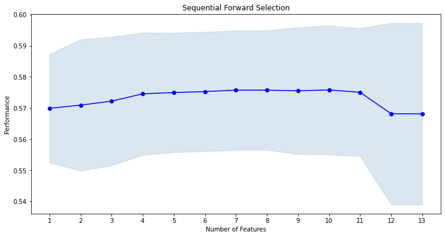

```python
from mlxtend.plotting import plot_sequential_feature_selection as plot_sfs

plot_sfs(sfs.get_metric_dict())
plt.title('Sequential Forward Selection')

plt.show()                 #visualization of the change in performance with regards to different number of variables
```

```python
X_train_sfs = sfs.transform(X_train)
X_test_sfs = sfs.transform(X_test)

clf.fit(X_train_sfs, np.ravel(y_train.values))
y_pred = clf.predict(X_test_sfs)
```

```python
roc_auc_score(y_test, y_pred)   #the results on the test and training data are very close to each other
```

```
0.5734153164735889
```

#### Backward Selection

```python
from sklearn.feature_selection import RFECV
clf = LogisticRegression(random_state=888, max_iter=10000, tol=0.001)

rfecv = RFECV(estimator=clf, step=1, cv=2, scoring='accuracy')
X_train_new = rfecv.fit(X_train,  np.ravel(y_train.values))

print('Optimal number of features: {}'.format(rfecv.n_features_))
```

```
Optimal number of features: 4
```

```python
X_train.columns[rfecv.support_]    #an interesting result, the variables that were found to be the most predictive, namely the
#brand id and item id by the filter methods table are not chosen here.
```

```
Index(['item_price', 'item_color_woe', 'user_state_woe', 'item_size_cat_woe'], dtype='object')
```

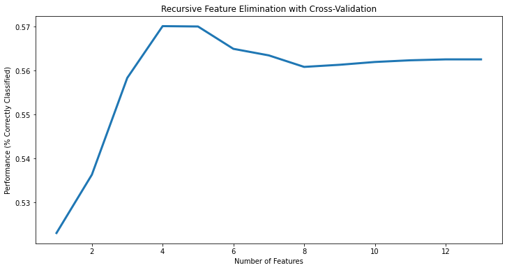

```python
plt.title('Recursive Feature Elimination with Cross-Validation')
plt.xlabel('Number of Features')
plt.ylabel('Performance (% Correctly Classified)')
plt.plot(range(1, len(rfecv.grid_scores_) + 1), rfecv.grid_scores_, linewidth=3)

plt.show()
```

```python
y_pred = rfecv.predict(X_test)  #the results are worse compared to the model before.

roc_auc_score(y_test, y_pred)
```

```
0.569390604186715
```

## Building the Models

Outline:

- Logit
- Decision Trees
- Cross Validation
- Hyperparameter tuning
- Bias-Variance Trade-off
- Random Forests
- Extreme Boosting
- Cost-sensitive Analysis

### Logistic Regression

Logistic regression is a good candidate for classification problems, where it calculates probabilities by minimizing the negative log-likelihood function using gradient descent.

#### Sm_logit Model

```python
X_train.info()

X_train_table = X_train.drop(['user_title_woe', 'user_state_woe', 'user_age', 'user_reg_time', 'order_day', 'delivery_day',
                              'delivery_dur', 'item_size_num'], axis=1)  #Variables kept according to the Filter methods table
X_test_table = X_test.drop(['user_title_woe', 'user_state_woe', 'user_age', 'user_reg_time', 'order_day', 'delivery_day',
                              'delivery_dur', 'item_size_num'], axis=1)
```

```
<class 'pandas.core.frame.DataFrame'>
Int64Index: 62565 entries, 2 to 99999
Data columns (total 13 columns):
 #   Column             Non-Null Count  Dtype
---  ------             --------------  -----
 0   delivery_dur       62565 non-null  float32
 1   item_size_num      62565 non-null  float32
 2   order_day          62565 non-null  float32
 3   user_reg_time      62565 non-null  float32
 4   item_id            62565 non-null  float32
 5   item_price         62565 non-null  float32
 6   delivery_day       62565 non-null  float32
 7   user_age           62565 non-null  float32
 8   brand_id           62565 non-null  float32
 9   item_color_woe     62565 non-null  float64
 10  user_state_woe     62565 non-null  float64
 11  user_title_woe     62565 non-null  float64
 12  item_size_cat_woe  62565 non-null  float64
dtypes: float32(9), float64(4)
memory usage: 7.0 MB
```

```python
dfk_all = pd.concat([dfk_train, dfk_test])
dfk_all
```

|  | item_id | item_color | brand_id | item_price | user_title | user_state | return | user_age | user_reg_time | order_day | delivery_day | delivery_dur | item_size_cat | item_size_num |
| --- | --- | --- | --- | --- | --- | --- | --- | --- | --- | --- | --- | --- | --- | --- |
| 2 | -0.425163 | grey | -0.0510993 | 0.598029 | Mrs | Baden-Wuerttemberg | 1 | -0.728799 | 1.119513 | 1.588901 | 1.437021 | -0.175918 | xxl | -0.184952 |
| 3 | 1.00499 | grey | -0.0510993 | 0.981662 | Mrs | Baden-Wuerttemberg | 0 | -0.728799 | 1.119513 | 1.588901 | 1.437021 | -0.175918 | xxl | -0.184952 |
| 5 | -0.309651 | grey | -0.231268 | -1.285924 | Mrs | Baden-Wuerttemberg | 1 | -0.728799 | 1.119513 | 1.588901 | 1.437021 | -0.175918 | xxl | -0.184952 |
| 6 | 0.573365 | grey | 0.140224 | 1.314432 | Mrs | Baden-Wuerttemberg | 0 | -0.728799 | 1.119513 | 1.588901 | 1.437021 | -0.175918 | numeric | 0.178792 |
| 8 | 0.89586 | blue | 0.332841 | -1.652637 | Mrs | Baden-Wuerttemberg | 1 | -0.728799 | 1.119513 | 1.588901 | 1.437021 | -0.175918 | xxl | -0.184952 |
| ... | ... | ... | ... | ... | ... | ... | ... | ... | ... | ... | ... | ... | ... | ... |
| 99989 | 0.0320923 | berry | 0.0320923 | -1.416586 | Mrs | Lower Saxony | 1 | -0.004603 | -0.412536 | -1.714263 | -1.240336 | -0.506300 | unsized | -0.184952 |
| 99991 | 0.223148 | pink | 0.162712 | -0.034726 | Mrs | Baden-Wuerttemberg | 1 | 0.719593 | 1.119513 | -1.714263 | -1.275107 | -0.489433 | numeric | 0.143305 |
| 99994 | -0.30438 | green | 0.0320923 | 1.972933 | Mrs | Baden-Wuerttemberg | 0 | 0.719593 | 1.119513 | -1.714263 | -1.275107 | -0.489433 | xl | -0.184952 |
| 99995 | -0.603896 | blue | -0.667881 | -0.748864 | Mrs | Rhineland-Palatinate | 0 | 0.719593 | 1.119513 | -1.714263 | -1.240336 | -0.506300 | numeric | -0.007516 |
| 99996 | -0.603896 | brown | -0.667881 | -0.748864 | Mrs | Rhineland-Palatinate | 0 | 0.719593 | 1.119513 | -1.714263 | -1.240336 | -0.506300 | numeric | -0.007516 |

89552 rows × 14 columns

```python
X_table_all = pd.concat([X_train_table, X_test_table])

X_table_all
```

|  | item_id | item_price | brand_id | item_color_woe | item_size_cat_woe |
| --- | --- | --- | --- | --- | --- |
| 2 | -0.425163 | 0.598029 | -0.051099 | 0.057569 | -0.145145 |
| 3 | 1.004988 | 0.981662 | -0.051099 | 0.057569 | -0.145145 |
| 5 | -0.309651 | -1.285924 | -0.231268 | 0.057569 | -0.145145 |
| 6 | 0.573365 | 1.314432 | 0.140224 | 0.057569 | 0.147280 |
| 8 | 0.895860 | -1.652637 | 0.332841 | 0.040627 | -0.145145 |
| ... | ... | ... | ... | ... | ... |
| 99989 | 0.032092 | -1.416586 | 0.032092 | -0.100640 | -0.857170 |
| 99991 | 0.223148 | -0.034726 | 0.162712 | -0.066679 | 0.147280 |
| 99994 | -0.304380 | 1.972933 | 0.032092 | -0.136505 | -0.054457 |
| 99995 | -0.603896 | -0.748864 | -0.667881 | 0.040627 | 0.147280 |
| 99996 | -0.603896 | -0.748864 | -0.667881 | 0.148795 | 0.147280 |

89552 rows × 5 columns

```python
import statsmodels.api as sm
sm_logit_all = sm.Logit(y_train.sort_index(), X_train.astype(float)).fit(method='bfgs')
print(sm_logit_all.summary())
```

```
                           Logit Regression Results
==============================================================================
Dep. Variable:                 return   No. Observations:                62565
Model:                          Logit   Df Residuals:                    62553
Method:                           MLE   Df Model:                           11
Date:                Fri, 16 Apr 2021   Pseudo R-squ.:                 0.02800
Time:                        00:13:45   Log-Likelihood:                -42147.
converged:                      False   LL-Null:                       -43361.
Covariance Type:            nonrobust   LLR p-value:                     0.000
=====================================================================================
                        coef    std err          z      P>|z|      [0.025      0.975]
-------------------------------------------------------------------------------------
delivery_dur         -0.0536        nan        nan        nan         nan         nan
item_size_num        -0.0211        nan        nan        nan         nan         nan
order_day             0.0047        nan        nan        nan         nan         nan
user_reg_time         0.0667        nan        nan        nan         nan         nan
item_id              -0.0306        nan        nan        nan         nan         nan
item_price            0.3379        nan        nan        nan         nan         nan
delivery_day          0.0291        nan        nan        nan         nan         nan
user_age             -0.1162        nan        nan        nan         nan         nan
brand_id              0.0082        nan        nan        nan         nan         nan
item_color_woe        0.3859        nan        nan        nan         nan         nan
user_state_woe        0.2994        nan        nan        nan         nan         nan
user_title_woe             0        nan        nan        nan         nan         nan
item_size_cat_woe     0.4371        nan        nan        nan         nan         nan
=====================================================================================
```

Sm.logit() function can also be used for interpretation means. From the summary above, when we look at the coefficients we see item price, item color, categorical item size and maybe user age to be found significant because of their higher weight in the model.

```python
y_pred = sm_logit_all.predict(X_train.astype(float)) #a plain logit model gives the following result with all the variables
roc_auc_score(y_train.sort_index(), y_pred)
```

```
0.6084357543831644
```

```python
y_pred = sm_logit_all.predict(X_test.astype(float)) #however slightly lower result on the test set as one might expect.
roc_auc_score(y_test.sort_index(), y_pred)
```

```
0.6027104835215437
```

```python
X_train
```

|  | delivery_dur | item_size_num | order_day | user_reg_time | item_id | item_price | delivery_day | user_age | brand_id | item_color_woe | user_state_woe | user_title_woe | item_size_cat_woe |
| --- | --- | --- | --- | --- | --- | --- | --- | --- | --- | --- | --- | --- | --- |
| 2 | -0.175918 | -0.184952 | 1.588901 | 1.119513 | -0.425163 | 0.598029 | 1.437021 | -0.728799 | -0.051099 | 0.057569 | -0.010570 | 0.0 | -0.145145 |
| 3 | -0.175918 | -0.184952 | 1.588901 | 1.119513 | 1.004988 | 0.981662 | 1.437021 | -0.728799 | -0.051099 | 0.057569 | -0.010570 | 0.0 | -0.145145 |
| 5 | -0.175918 | -0.184952 | 1.588901 | 1.119513 | -0.309651 | -1.285924 | 1.437021 | -0.728799 | -0.231268 | 0.057569 | -0.010570 | 0.0 | -0.145145 |
| 6 | -0.175918 | 0.178792 | 1.588901 | 1.119513 | 0.573365 | 1.314432 | 1.437021 | -0.728799 | 0.140224 | 0.057569 | -0.010570 | 0.0 | 0.147280 |
| 8 | -0.175918 | -0.184952 | 1.588901 | 1.119513 | 0.895860 | -1.652637 | 1.437021 | -0.728799 | 0.332841 | 0.040627 | -0.010570 | 0.0 | -0.145145 |
| ... | ... | ... | ... | ... | ... | ... | ... | ... | ... | ... | ... | ... | ... |
| 99988 | -0.473407 | -0.184952 | -1.714263 | -0.412536 | 0.093513 | -0.443122 | -1.240336 | -0.004603 | 0.365819 | -0.160293 | 0.019601 | 0.0 | -0.857170 |
| 99990 | 1.460274 | -0.184952 | -1.714263 | -0.412536 | 0.874120 | 0.380310 | -2.144379 | -0.004603 | 1.044854 | -0.160293 | 0.019601 | 0.0 | -0.016012 |
| 99992 | -0.399035 | 0.143305 | -1.714263 | 1.119513 | -0.267978 | 0.139511 | -1.275107 | 0.719593 | 0.140224 | 0.040627 | -0.010570 | 0.0 | 0.147280 |
| 99993 | -0.399035 | 0.240894 | -1.714263 | 1.119513 | 0.026822 | 0.380310 | -1.275107 | 0.719593 | 1.250597 | -0.100640 | -0.010570 | 0.0 | 0.147280 |
| 99999 | 1.460274 | 0.063459 | -1.714263 | 1.119513 | 0.026822 | -0.899451 | -2.144379 | -1.090897 | 0.333481 | -0.136505 | 0.019601 | 0.0 | 0.147280 |

62565 rows × 13 columns

```python
X_train_copy
```

|  | item_id | item_color | brand_id | item_price | user_title | user_state | user_age | user_reg_time | order_day | delivery_day | delivery_dur | item_size_cat | item_size_num |
| --- | --- | --- | --- | --- | --- | --- | --- | --- | --- | --- | --- | --- | --- |
| 2 | -0.425163 | grey | -0.0510993 | 0.598029 | Mrs | Baden-Wuerttemberg | -0.728799 | 1.119513 | 1.588901 | 1.437021 | -0.175918 | xxl | -0.184952 |
| 3 | 1.00499 | grey | -0.0510993 | 0.981662 | Mrs | Baden-Wuerttemberg | -0.728799 | 1.119513 | 1.588901 | 1.437021 | -0.175918 | xxl | -0.184952 |
| 5 | -0.309651 | grey | -0.231268 | -1.285924 | Mrs | Baden-Wuerttemberg | -0.728799 | 1.119513 | 1.588901 | 1.437021 | -0.175918 | xxl | -0.184952 |
| 6 | 0.573365 | grey | 0.140224 | 1.314432 | Mrs | Baden-Wuerttemberg | -0.728799 | 1.119513 | 1.588901 | 1.437021 | -0.175918 | numeric | 0.178792 |
| 8 | 0.89586 | blue | 0.332841 | -1.652637 | Mrs | Baden-Wuerttemberg | -0.728799 | 1.119513 | 1.588901 | 1.437021 | -0.175918 | xxl | -0.184952 |
| ... | ... | ... | ... | ... | ... | ... | ... | ... | ... | ... | ... | ... | ... |
| 99988 | 0.0935131 | petrol | 0.365819 | -0.443122 | Mrs | Lower Saxony | -0.004603 | -0.412536 | -1.714263 | -1.240336 | -0.473407 | unsized | -0.184952 |
| 99990 | 0.87412 | petrol | 1.04485 | 0.380310 | Mrs | Lower Saxony | -0.004603 | -0.412536 | -1.714263 | -2.144379 | 1.460274 | l | -0.184952 |
| 99992 | -0.267978 | black | 0.140224 | 0.139511 | Mrs | Baden-Wuerttemberg | 0.719593 | 1.119513 | -1.714263 | -1.275107 | -0.399035 | numeric | 0.143305 |
| 99993 | 0.0268217 | anthracite | 1.2506 | 0.380310 | Mrs | Baden-Wuerttemberg | 0.719593 | 1.119513 | -1.714263 | -1.275107 | -0.399035 | numeric | 0.240894 |
| 99999 | 0.0268217 | fuchsia | 0.333481 | -0.899451 | Mrs | Lower Saxony | -1.090897 | 1.119513 | -1.714263 | -2.144379 | 1.460274 | numeric | 0.063459 |

62565 rows × 13 columns

```python
X_train_copy = X_train.copy()
X_test_copy = X_test.copy()

X_train_copy2 = X_train.copy()
X_test_copy2 = X_test.copy()
```

```python
#X_train = X_train_copy2 #for refreshing in case of errors below
#X_test = X_test_copy2
```

```python
X_train_copy2
```

|  | delivery_dur | item_size_num | order_day | user_reg_time | item_id | item_price | delivery_day | user_age | brand_id | item_color_woe | user_state_woe | user_title_woe | item_size_cat_woe |
| --- | --- | --- | --- | --- | --- | --- | --- | --- | --- | --- | --- | --- | --- |
| 2 | -0.175918 | -0.184952 | 1.588901 | 1.119513 | -0.425163 | 0.598029 | 1.437021 | -0.728799 | -0.051099 | 0.057569 | -0.010570 | 0.0 | -0.145145 |
| 3 | -0.175918 | -0.184952 | 1.588901 | 1.119513 | 1.004988 | 0.981662 | 1.437021 | -0.728799 | -0.051099 | 0.057569 | -0.010570 | 0.0 | -0.145145 |
| 5 | -0.175918 | -0.184952 | 1.588901 | 1.119513 | -0.309651 | -1.285924 | 1.437021 | -0.728799 | -0.231268 | 0.057569 | -0.010570 | 0.0 | -0.145145 |
| 6 | -0.175918 | 0.178792 | 1.588901 | 1.119513 | 0.573365 | 1.314432 | 1.437021 | -0.728799 | 0.140224 | 0.057569 | -0.010570 | 0.0 | 0.147280 |
| 8 | -0.175918 | -0.184952 | 1.588901 | 1.119513 | 0.895860 | -1.652637 | 1.437021 | -0.728799 | 0.332841 | 0.040627 | -0.010570 | 0.0 | -0.145145 |
| ... | ... | ... | ... | ... | ... | ... | ... | ... | ... | ... | ... | ... | ... |
| 99988 | -0.473407 | -0.184952 | -1.714263 | -0.412536 | 0.093513 | -0.443122 | -1.240336 | -0.004603 | 0.365819 | -0.160293 | 0.019601 | 0.0 | -0.857170 |
| 99990 | 1.460274 | -0.184952 | -1.714263 | -0.412536 | 0.874120 | 0.380310 | -2.144379 | -0.004603 | 1.044854 | -0.160293 | 0.019601 | 0.0 | -0.016012 |
| 99992 | -0.399035 | 0.143305 | -1.714263 | 1.119513 | -0.267978 | 0.139511 | -1.275107 | 0.719593 | 0.140224 | 0.040627 | -0.010570 | 0.0 | 0.147280 |
| 99993 | -0.399035 | 0.240894 | -1.714263 | 1.119513 | 0.026822 | 0.380310 | -1.275107 | 0.719593 | 1.250597 | -0.100640 | -0.010570 | 0.0 | 0.147280 |
| 99999 | 1.460274 | 0.063459 | -1.714263 | 1.119513 | 0.026822 | -0.899451 | -2.144379 | -1.090897 | 0.333481 | -0.136505 | 0.019601 | 0.0 | 0.147280 |

62565 rows × 13 columns

```python
X_train.drop(['user_state_woe', 'user_title_woe', 'user_reg_time',  #kept user_age here
              'delivery_dur', 'delivery_day', 'order_day', 'item_size_num'], axis=1, inplace = True)
X_test.drop(['user_state_woe', 'user_title_woe', 'user_reg_time',
              'delivery_dur', 'delivery_day', 'order_day', 'item_size_num'], axis=1, inplace = True)
```

```python
sm_logit_ = sm.Logit(y_train.sort_index(), X_train.astype(float)).fit(method='bfgs')

y_pred = sm_logit_.predict(X_train.astype(float))
print(roc_auc_score(y_train.sort_index(), y_pred))

y_pred = sm_logit_.predict(X_test.astype(float)) #slightly lower AUC score than the case where all variables were included
print(roc_auc_score(y_test.sort_index(), y_pred))
```

```
Optimization terminated successfully.
         Current function value: 0.675022
         Iterations: 32
         Function evaluations: 33
         Gradient evaluations: 33
0.6045536765867585
0.6010285276958167
```

```python
X_train.drop(['user_age'], axis=1, inplace = True)  #omitted user age too
X_test.drop(['user_age'], axis=1, inplace = True)
```

```python
sm_logit_table = sm.Logit(y_train.sort_index(), X_train_table.astype(float)).fit(method='bfgs')

y_pred = sm_logit_table.predict(X_train_table.astype(float)) #worse result #here user age is also omitted
print(roc_auc_score(y_train.sort_index(), y_pred)) #This iteration was made because user age was highest among the low fisher values
                                                #and to see whether it will improve or decrease the performance of the model
y_pred = sm_logit_table.predict(X_test_table.astype(float))
print(roc_auc_score(y_test.sort_index(), y_pred))
```

```
Optimization terminated successfully.
         Current function value: 0.676395
         Iterations: 29
         Function evaluations: 30
         Gradient evaluations: 30
0.6003512661355925
0.5970796335524154
```

So, although by the filter method table user age was found not to be predictive of the return behavior, we see here that that doesn't mean it is not predictive at all but rather a very small amount.

```python
X_train = X_train_copy2 #for refreshing in case of errors below
X_test = X_test_copy2  #left here!
```

```python
X_train.info()
```

```
<class 'pandas.core.frame.DataFrame'>
Int64Index: 62565 entries, 2 to 99999
Data columns (total 13 columns):
 #   Column             Non-Null Count  Dtype
---  ------             --------------  -----
 0   delivery_dur       62565 non-null  float32
 1   item_size_num      62565 non-null  float32
 2   order_day          62565 non-null  float32
 3   user_reg_time      62565 non-null  float32
 4   item_id            62565 non-null  float32
 5   item_price         62565 non-null  float32
 6   delivery_day       62565 non-null  float32
 7   user_age           62565 non-null  float32
 8   brand_id           62565 non-null  float32
 9   item_color_woe     62565 non-null  float64
 10  user_state_woe     62565 non-null  float64
 11  user_title_woe     62565 non-null  float64
 12  item_size_cat_woe  62565 non-null  float64
dtypes: float32(9), float64(4)
memory usage: 4.5 MB
```